# IODS course project

Tuomas KJ Heikkilä

# Introduction to Open Data Science - Course Project

# About the project

My name is **Tuomas Heikkilä**. I am a Phd student in Media and Communication studies at University of Helsinki, working primarily with social media datasets and computational social sciences methods, that command fluency in API querying, web scraping, data wrangling, data visualization and (light) statistical analaysis - all skills this course can hopefully help me with.

I am especially looking forward to kickstarting my R skills, having already some experience with python.

You can find [my GitHub repository here](https://github.com/tuohmas/IODS-project).

# Exercise 2, Week 2: Regression and model validation

This week, we are working with student questionaire (“learning2014” dataset), exploring the teaching and learning on introduction to statistics in social sciences course at University of Helsinki in 2014. For a detailed description about the dataset, [pleaset see the data code book](https://www.mv.helsinki.fi/home/kvehkala/JYTmooc/JYTOPKYS2-meta.txt) (in Finnish)

We will base our analysis on four original variables and three sum variables:

| Variable | Description |
| --- | --- |
| age | Age (in years) derived from the date of birth |
| attitude | Global attitude toward statistics |
| points | Exam points |
| gender | Gender: M (Male), F (Female) |
| deep | A sum variable for *deep learning* that consists of “D03”, “D11”, “D19”, “D27”, “D07”, “D14”, “D22”, “D30”,“D06”, “D15”, “D23”, and “D31” (see codebook above) |
| stra | A sum variable for *strategic learning* that consists of “SU02”,“SU10”,“SU18”,“SU26”, “SU05”,“SU13”,“SU21”,“SU29”,“SU08”,“SU16”,“SU24”, and “SU32” (see codebook above) |
| surf | A sum variable for *surface learning* that consists of “ST01”,“ST09”,“ST17”,“ST25”,“ST04”,“ST12”,“ST20”, and “ST28” (see codebook above) |

Let us begin by reading learning data csv file – prepared earlier – as a data.frame from repo:

```r
library(tidyverse)
learning2014 <- read.table("https://raw.githubusercontent.com/tuohmas/IODS-project/master/data/learning2014.csv",
                           sep = ",", header = TRUE)
glimpse(learning2014)
```

```
## Rows: 166
## Columns: 7
## $ gender   <chr> "F", "M", "F", "M", "M", "F", "M", "F", "M", "F", "M", "F", "~
## $ age      <int> 53, 55, 49, 53, 49, 38, 50, 37, 37, 42, 37, 34, 34, 34, 35, 3~
## $ attitude <int> 37, 31, 25, 35, 37, 38, 35, 29, 38, 21, 39, 38, 24, 30, 26, 4~
## $ deep     <dbl> 3.583333, 2.916667, 3.500000, 3.500000, 3.666667, 4.750000, 3~
## $ stra     <dbl> 3.375, 2.750, 3.625, 3.125, 3.625, 3.625, 2.250, 4.000, 4.250~
## $ surf     <dbl> 2.583333, 3.166667, 2.250000, 2.250000, 2.833333, 2.416667, 1~
## $ points   <int> 25, 12, 24, 10, 22, 21, 21, 31, 24, 26, 31, 31, 23, 25, 21, 3~
```

To get a handle of our variables, we will plot attitude against exam points as a scatter plot, and use gender as an aesthetic element. Finally, let’s add a regression line layer with 95% confidence interval:

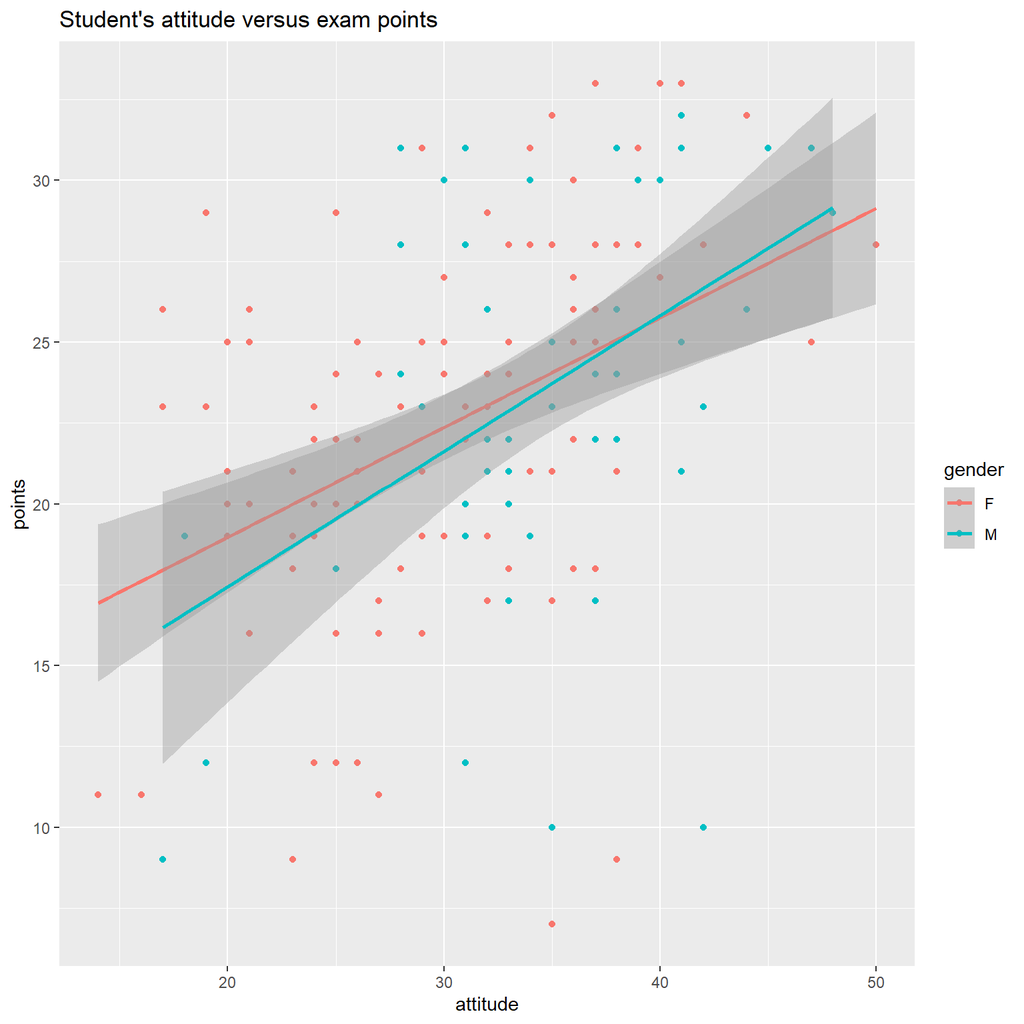

```r
library(ggplot2)

# initialize plot with data and aesthetic mapping
plot <- ggplot(learning2014, aes(x = attitude, y = points, col = gender)) +
  geom_point() +# define the visualization type (points)
  geom_smooth(method = "lm") + # add a regression line
  # add a main title and draw the plot
  ggtitle("Student's attitude versus exam points")

plot
```

As we can see, a clear positive association between attitude versus exam points exists. Let’s explore this linear relationship further with multiple regression model.

## Multiple regression model

Now we can begin to work with a regression model that would predict student exam points.

Let’s consider pearson correlations between our variables. Visually, this is neatly done with a plot matrix using a ggpairs() function, available with GGally library.

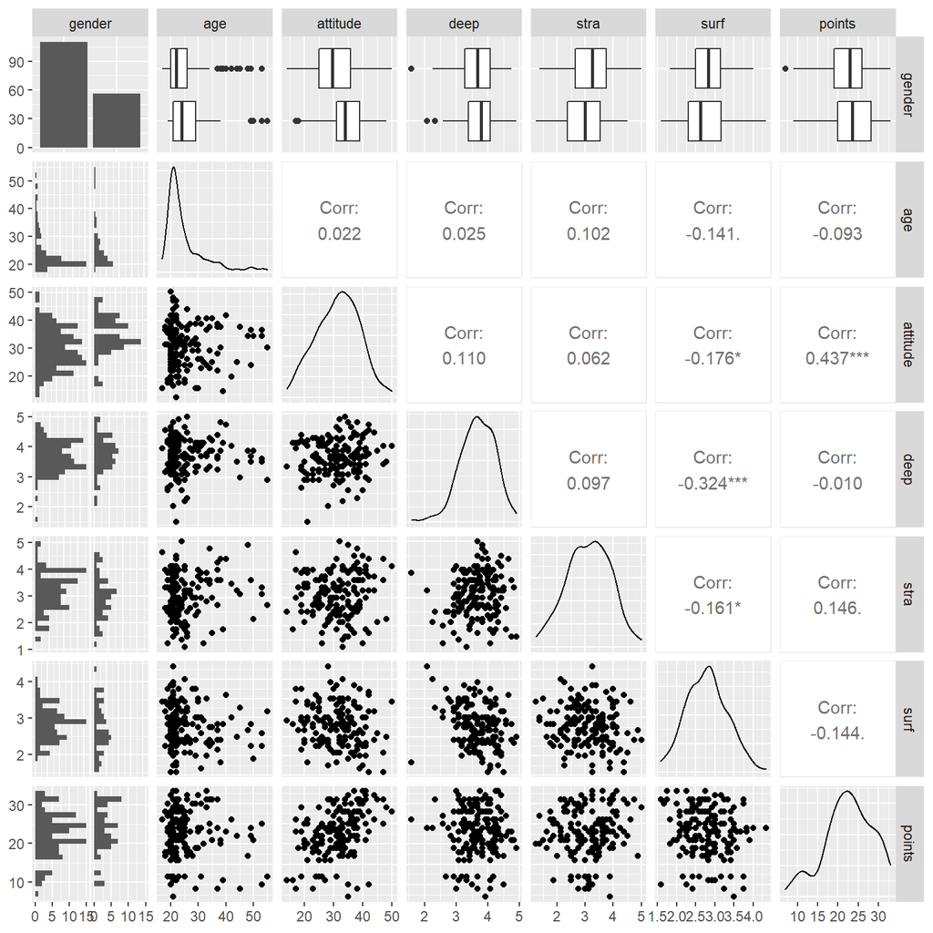

```r
library(GGally)

ggpairs(learning2014, lower = list(combo = wrap("facethist", bins = 20)))
```

We might hypothesize that we can predict points as target variables using three explanatory variables.

As the most promising candidates, let’s choose the three variables with the highest absolute correlations with points, namely

1. **attitude (var name “attitude”)**, Pearson correlation 0.437;
2. **strategic learning (stra)**, correlation 0.146; and
3. **surface learning (surf)**, correlation -0.144.

Note that, by convention, correlation sizes under 0.30 might be interpreted as negligible, casting some doubt over our second and third explanatory variables.

Now we can create a linear model that takes points attitude, stra and surf as explanatory variables. Let’s then print out a summary of the model.

```r
my_model1 <- lm(points ~ attitude + stra + surf, data = learning2014)
summary(my_model1)
```

```
##
## Call:
## lm(formula = points ~ attitude + stra + surf, data = learning2014)
##
## Residuals:
##      Min       1Q   Median       3Q      Max
## -17.1550  -3.4346   0.5156   3.6401  10.8952
##
## Coefficients:
##             Estimate Std. Error t value Pr(>|t|)
## (Intercept) 11.01711    3.68375   2.991  0.00322 **
## attitude     0.33952    0.05741   5.913 1.93e-08 ***
## stra         0.85313    0.54159   1.575  0.11716
## surf        -0.58607    0.80138  -0.731  0.46563
## ---
## Signif. codes:  0 '***' 0.001 '**' 0.01 '*' 0.05 '.' 0.1 ' ' 1
##
## Residual standard error: 5.296 on 162 degrees of freedom
## Multiple R-squared:  0.2074, Adjusted R-squared:  0.1927
## F-statistic: 14.13 on 3 and 162 DF,  p-value: 3.156e-08
```

From the summary we see that explanatory variable *attitude* passes null-hypothesis test with flying colors ($p < 1.93×10^{-8}$). However, *stra* and *surf* variables should be excluded from our model, as neither of their beta coefficents – that quantifies the relationship between the target variable and the explanatory variable – is statistically significantly different from zero, indicating no relationship with our preferred risk-level 0.05.

Let’s go back and fix the model so that only statistically significant explanatory variables, namely the *attitude*, are included, and interpret the summary.

```r
my_model2 <- lm(points ~ attitude, data = learning2014)
summary(my_model2)
```

```
##
## Call:
## lm(formula = points ~ attitude, data = learning2014)
##
## Residuals:
##      Min       1Q   Median       3Q      Max
## -16.9763  -3.2119   0.4339   4.1534  10.6645
##
## Coefficients:
##             Estimate Std. Error t value Pr(>|t|)
## (Intercept) 11.63715    1.83035   6.358 1.95e-09 ***
## attitude     0.35255    0.05674   6.214 4.12e-09 ***
## ---
## Signif. codes:  0 '***' 0.001 '**' 0.01 '*' 0.05 '.' 0.1 ' ' 1
##
## Residual standard error: 5.32 on 164 degrees of freedom
## Multiple R-squared:  0.1906, Adjusted R-squared:  0.1856
## F-statistic: 38.61 on 1 and 164 DF,  p-value: 4.119e-09
```

Let’s remind ourselves that we are modelling exam points with simple linear equation $y = \alpha+\beta x+\epsilon$, where

- $y$ is the target variable (points),
- $x$ is explanatory variable (attitude),
- $\beta$ parameter quantifies the relationship between $y$ and $x$ (visualised as the slope of the regression line),
- $\alpha$ is a constant parameter that (visualised as the point where regression line intersects the y axis); and
- $\epsilon$ is an unobservable random variable that estimates the error (residual) inherent in the model.

With that in mind, let’s see what our summary table holds.

- Estimate of the constant parameter is positive and quite high ($\alpha = 11.63$), with very high certainty of being non-zero ($p < 1.95×10^{-9}$)
- Estimated effect of attitude is positive ($\beta=0.352$). From associated *F*-test we can determine that the beta coefficient is significantly different from zero ($p < 4.12×10^{-9}$), pointing to statistically very significant relationship between $y$ and $x$.
- Based on a *F*-test, our model explains a significant amount of variance in the outcome variable, with very low risk level ($F(1, 164) = 38.61, p < 4.12×10^{-9}$)
- Multiple $R^{2}$ tells us that 19.1% of the variation in exam points can be explained by our attitude variable.

## Diagnostics: how well does our model satisfy the core assumptions of linear regression analysis?

Finally, let’s explore how well our fitted model satisfies the core assumptions of linear regression model.

To assess our model further, let’s finally run three diagnostic plots:

- **Residuals vs Fitted** allows us to explore the assumption that model errors are not dependent on explanatory variables.
- **Normal QQ-plot** allows us to explore the assumption that the errors of our model are normally distributed.
- **Residuals vs Leverage** allows us to explore if our data contains any observations that have exceptionally high impact on our model.

We will above plots using the plot() function using the argument which, to which we pass a vector c(1, 2, 5): each integer corresponding to the graphics above. We will also initialize the parameter so that plot appear in more conveniently.

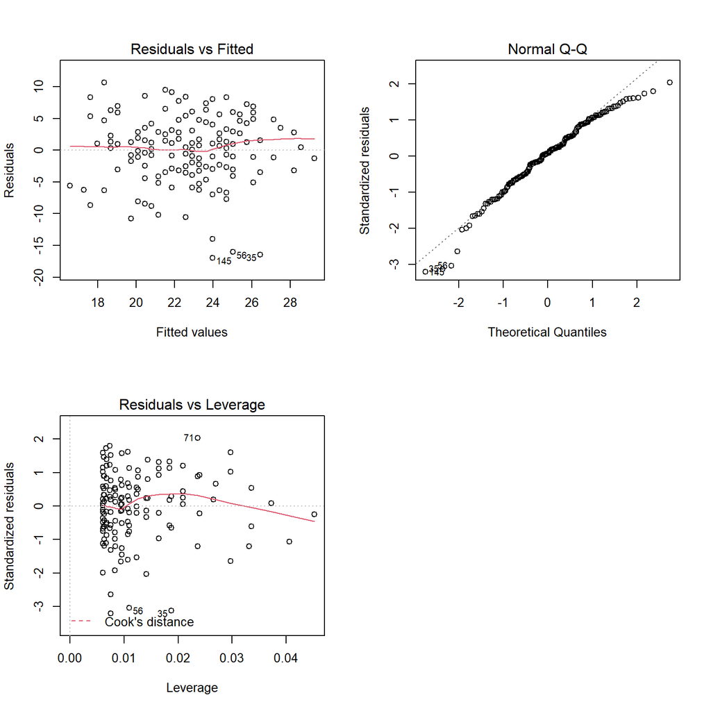

```r
par(mfrow = c(2,2))
plot(my_model2, which = c(1, 2, 5))
```

# Exercise 3, Week 3: Logistic regression

This week, we will be modeling student’s alcohol consumption using logistic regression analysis. We will be working with Student Performance Data Set provided by UC Irvine Machine Learning Repository. For a detailed data description, [please see Student Performance Data Set Attribute Information here](https://archive.ics.uci.edu/ml/datasets/Student+Performance).

We have previously merged together participants from Math course (student-math.csv) and Portuguese language course datasets (student-por.csv). We will start with loading the common alc.csv to memory.

```r
library(tidyverse)

alc <- read.table("https://github.com/tuohmas/IODS-project/raw/master/data/alc.csv",
                           sep = ";", header = TRUE)

glimpse(alc)
```

```
## Rows: 370
## Columns: 33
## $ school     <chr> "GP", "GP", "GP", "GP", "GP", "GP", "GP", "GP", "GP", "GP",~
## $ sex        <chr> "F", "F", "F", "F", "F", "F", "F", "F", "F", "F", "F", "F",~
## $ age        <int> 15, 15, 15, 15, 15, 15, 15, 15, 15, 15, 15, 15, 15, 15, 15,~
## $ address    <chr> "R", "R", "R", "R", "R", "R", "R", "R", "R", "U", "U", "U",~
## $ famsize    <chr> "GT3", "GT3", "GT3", "GT3", "GT3", "GT3", "GT3", "LE3", "LE~
## $ Pstatus    <chr> "T", "T", "T", "T", "T", "T", "T", "T", "T", "A", "A", "T",~
## $ Medu       <int> 1, 1, 2, 2, 3, 3, 3, 2, 3, 3, 4, 1, 1, 1, 1, 1, 2, 2, 2, 3,~
## $ Fedu       <int> 1, 1, 2, 4, 3, 4, 4, 2, 1, 3, 3, 1, 1, 1, 2, 2, 1, 2, 3, 2,~
## $ Mjob       <chr> "at_home", "other", "at_home", "services", "services", "ser~
## $ Fjob       <chr> "other", "other", "other", "health", "services", "health", ~
## $ reason     <chr> "home", "reputation", "reputation", "course", "reputation",~
## $ guardian   <chr> "mother", "mother", "mother", "mother", "other", "mother", ~
## $ traveltime <int> 2, 1, 1, 1, 2, 1, 2, 2, 2, 1, 1, 3, 1, 1, 1, 1, 3, 1, 2, 1,~
```

[output cut: 20 more lines]

```r
summary(alc)
```

```
##     school              sex                 age          address
##  Length:370         Length:370         Min.   :15.00   Length:370
##  Class :character   Class :character   1st Qu.:16.00   Class :character
##  Mode  :character   Mode  :character   Median :17.00   Mode  :character
##                                        Mean   :16.58
##                                        3rd Qu.:17.00
##                                        Max.   :22.00
##    famsize            Pstatus               Medu          Fedu
##  Length:370         Length:370         Min.   :0.0   Min.   :0.000
##  Class :character   Class :character   1st Qu.:2.0   1st Qu.:2.000
##  Mode  :character   Mode  :character   Median :3.0   Median :3.000
##                                        Mean   :2.8   Mean   :2.557
##                                        3rd Qu.:4.0   3rd Qu.:3.750
##                                        Max.   :4.0   Max.   :4.000
##      Mjob               Fjob              reason            guardian
##  Length:370         Length:370         Length:370         Length:370
##  Class :character   Class :character   Class :character   Class :character
##  Mode  :character   Mode  :character   Mode  :character   Mode  :character
##
##
##
##    traveltime      studytime      schoolsup            famsup
##  Min.   :1.000   Min.   :1.000   Length:370         Length:370
##  1st Qu.:1.000   1st Qu.:1.000   Class :character   Class :character
##  Median :1.000   Median :2.000   Mode  :character   Mode  :character
##  Mean   :1.446   Mean   :2.043
##  3rd Qu.:2.000   3rd Qu.:2.000
##  Max.   :4.000   Max.   :4.000
##   activities          nursery             higher            internet
##  Length:370         Length:370         Length:370         Length:370
##  Class :character   Class :character   Class :character   Class :character
##  Mode  :character   Mode  :character   Mode  :character   Mode  :character
##
##
##
##    romantic             famrel         freetime         goout
##  Length:370         Min.   :1.000   Min.   :1.000   Min.   :1.000
##  Class :character   1st Qu.:4.000   1st Qu.:3.000   1st Qu.:2.000
##  Mode  :character   Median :4.000   Median :3.000   Median :3.000
##                     Mean   :3.935   Mean   :3.224   Mean   :3.116
```

[output cut: 8 more lines]

```
##  Max.   :5.000   Max.   :5.000   Max.   :5.000
##      paid             absences              G1                 G2
##  Length:370         Length:370         Length:370         Length:370
##  Class :character   Class :character   Class :character   Class :character
##  Mode  :character   Mode  :character   Mode  :character   Mode  :character
##
##
##
##       G3
##  Length:370
##  Class :character
##  Mode  :character
##
##
##
```

### Data manipulation and graphical overview of alcohol consumption

```r
# define a new sum variable alc_use for overall alcohol use:
alc <- mutate(alc, alc_use = (Dalc + Walc) / 2)

# ...and boolean for heavy use (TRUE or FALSE)
alc <- mutate(alc, high_use = alc_use > 2)

# plot alcohol use by sex as bar chart
g1 <- ggplot(data = alc, aes(x = alc_use, fill = sex)) +
geom_bar() # define the plot as a bar plot and draw it

# draw a bar plot of high_use by sex
g2 <- ggplot(data = alc, aes(x = high_use)) +
geom_bar() + facet_wrap("sex")
```

### Logistic regression

We will now use logistic regression to identify factors related to higher than average student alcohol consumption.

Below I have used the glm() function to fit a logistic regression model with high_use as the target variable and four potential predictors:

- **student’s age** (age, interval: from 15 to 22), as it is likely that people consume more alcohol the younger they are (both attending more events where alcohol is used, and coping better with its aftermath, biologically)
- **student’s sex** (sex, binary: M or F), as metabolism and other sex-specific biological systems somewhat determine that can consume more alcohol than women to achieve similar end state.
- **weekly study time** (studytime, ordinal in approx. hours from less than 2 to more than 10) and **going out with friends** (goout, Likert-type scale from 1 - very low to 5 - very high), as these two measures are somewhat exclusionary, and studying implies not drinking alcohol, while socializing does.

```r
# find the model with glm()
m <- glm(high_use ~ age + sex + studytime + goout -1, data = alc, family = "binomial")

# print out a summary of the model
summary(m)
```

```
##
## Call:
## glm(formula = high_use ~ age + sex + studytime + goout - 1, family = "binomial",
##     data = alc)
##
## Deviance Residuals:
##     Min       1Q   Median       3Q      Max
## -1.7449  -0.8195  -0.5268   0.8691   2.6918
##
## Coefficients:
##           Estimate Std. Error z value Pr(>|z|)
## age         0.1151     0.1096   1.049  0.29397
## sexF       -4.5616     1.8631  -2.448  0.01435 *
## sexM       -3.8405     1.8436  -2.083  0.03724 *
## studytime  -0.4972     0.1706  -2.915  0.00356 **
## goout       0.7316     0.1204   6.076 1.23e-09 ***
## ---
## Signif. codes:  0 '***' 0.001 '**' 0.01 '*' 0.05 '.' 0.1 ' ' 1
##
## (Dispersion parameter for binomial family taken to be 1)
##
##     Null deviance: 512.93  on 370  degrees of freedom
## Residual deviance: 378.66  on 365  degrees of freedom
## AIC: 388.66
##
## Number of Fisher Scoring iterations: 4
```

Note that I have removed intercept from the model, so the Wald test has the null-hypothesis that all coefficents are zero, i.e., do not contribute to the model.

From the summary we see that sex, study time and going out all have statistically significant impact on the model. On the other hand, age does not seem to affect alcohol consumption – which we might have guessed, since minimum value (15 yo) is quite young, students’ median age is only 17, and maximum (22 yo) is just barely over legal drinking age in the US.

Excluding age and fit a new model with the rest of the predictors. Besides coefficents, let’s also print out their exponents:

```r
# find the model with glm()
m2 <- glm(high_use ~ sex + studytime + goout -1, data = alc, family = "binomial")

# print out a summary of the model
summary(m2)
```

```
##
## Call:
## glm(formula = high_use ~ sex + studytime + goout - 1, family = "binomial",
##     data = alc)
##
## Deviance Residuals:
##     Min       1Q   Median       3Q      Max
## -1.7372  -0.7992  -0.5161   0.8745   2.6371
##
## Coefficients:
##           Estimate Std. Error z value Pr(>|z|)
## sexF       -2.7096     0.5724  -4.734 2.20e-06 ***
## sexM       -1.9891     0.5139  -3.871 0.000108 ***
## studytime  -0.4949     0.1694  -2.921 0.003492 **
## goout       0.7486     0.1195   6.265 3.73e-10 ***
## ---
## Signif. codes:  0 '***' 0.001 '**' 0.01 '*' 0.05 '.' 0.1 ' ' 1
##
## (Dispersion parameter for binomial family taken to be 1)
##
##     Null deviance: 512.93  on 370  degrees of freedom
## Residual deviance: 379.77  on 366  degrees of freedom
## AIC: 387.77
##
## Number of Fisher Scoring iterations: 4
```

```r
# print out the coefficients of the model
coef(m2)
```

```
##       sexF       sexM  studytime      goout
## -2.7096474 -1.9890541 -0.4949109  0.7485730
```

```r
# compute odds ratios (OR)
OR <- coef(m2) %>% exp

# compute confidence intervals (CI)
CI <- confint(m2) %>% exp
# print out the odds ratios with their confidence intervals
cbind(OR, CI)
```

```
##                   OR      2.5 %    97.5 %
## sexF      0.06656027 0.02100527 0.1991994
## sexM      0.13682479 0.04872172 0.3671741
## studytime 0.60962523 0.43269168 0.8427333
## goout     2.11398128 1.68317666 2.6916806
```

All of our explanatory variable coefficient are now statistically different from zero, some substantially so, and thus contribute to the model.

### Predicted probabilities and the “confusion matrix”

We will use predict() function to our model (m2) and add it as a variable, then use that variable to predict high alcohol use with 50 % certainty:

```r
# predict() the probability of high_use
probabilities <- predict(m2, type = "response")

# add the predicted probabilities to 'alc'
alc <- mutate(alc, probability = probabilities)

# use the probabilities to make a prediction of high_use
alc <- mutate(alc, prediction = probability > 0.5)

# see the last ten original classes, predicted probabilities, and class predictions
select(alc, failures, absences, sex, high_use, probability, prediction) %>% tail(10)
```

```
##     failures absences sex high_use probability prediction
## 361        M        M   M     TRUE   0.4407187      FALSE
## 362        M        M   M     TRUE   0.4407187      FALSE
## 363        M        M   M     TRUE   0.1498992      FALSE
## 364        M        M   M     TRUE   0.5038540       TRUE
## 365        M        M   M    FALSE   0.2715409      FALSE
## 366        M        M   M     TRUE   0.4407187      FALSE
## 367        M        M   M    FALSE   0.1216774      FALSE
## 368        M        M   M     TRUE   0.6248832       TRUE
## 369        M        M   M     TRUE   0.5038540       TRUE
## 370        M        M   M    FALSE   0.2715409      FALSE
```

```r
# tabulate the target variable versus the predictions
table(high_use = alc$high_use, prediction = alc$prediction)
```

```
##         prediction
## high_use FALSE TRUE
##    FALSE   234   25
##    TRUE     58   53
```

### Models predictive power

We will explore our models’s predicit power

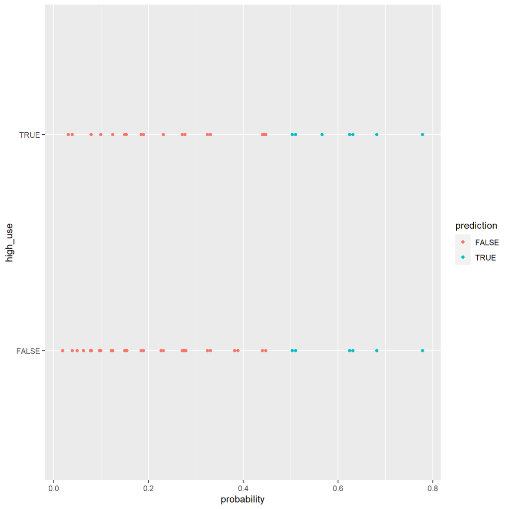

```r
# access dplyr and ggplot2
library(dplyr); library(ggplot2)

# initialize a plot of 'high_use' versus 'probability' in 'alc'
g <- ggplot(alc, aes(x = probability, y = high_use, col = prediction)) +
geom_point() # define the geom as points and draw the plot
g
```

```r
# tabulate the target variable versus the predictions
table(high_use = alc$high_use, prediction = alc$prediction) %>% prop.table() %>% addmargins()
```

```
##         prediction
## high_use      FALSE       TRUE        Sum
##    FALSE 0.63243243 0.06756757 0.70000000
##    TRUE  0.15675676 0.14324324 0.30000000
##    Sum   0.78918919 0.21081081 1.00000000
```

From the “confusion matrix” see that following proportions of misclassification: * in 6.7 % of cases prediction indicates high alcohol use (TRUE) while target variable indicated low-use (FALSE); and * in 15.7 % cases prediction indicated low-use while target variable indicates high-use.

### Model accuracy

Calculate our predictive model’s accuracy with a loss function:

```r
# define a loss function (average prediction error)
loss_func <- function(class, prob) {
  n_wrong <- abs(class - prob) > 0.5
  mean(n_wrong)
}

# call loss_func to compute the average number of wrong predictions in the (training) data
loss_func(class = alc$high_use, prob = alc$probability)
```

```
## [1] 0.2243243
```

```r
# K-fold cross-validation
library(boot)
cv <- cv.glm(data = alc, cost = loss_func, glmfit = m2, K = nrow(alc))

# average number of wrong predictions in the cross validation
cv$delta[1]
```

```
## [1] 0.2648649
```

# Exercise 4, Week 4: Clustering and classification

This week’s exercise is performed on dataset on Housing Values in Suburbs of Boston (Boston), available with MASS-package. [Full variable descriptions can be found here](https://stat.ethz.ch/R-manual/R-devel/library/MASS/html/Boston.html) or by calling ?MASS:Boston.

*Source:* Harrison, D. and Rubinfeld, D.L. (1978) Hedonic prices and the demand for clean air. *J. Environ. Economics and Management* **5**, 81–102. Belsley D.A., Kuh, E. and Welsch, R.E. (1980) *Regression Diagnostics. Identifying Influential Data and Sources of Collinearity*. New York: Wiley.

First, we will load Boston from MASS

```r
library(MASS)
data("Boston")

str(Boston)
```

```
## 'data.frame':    506 obs. of  14 variables:
##  $ crim   : num  0.00632 0.02731 0.02729 0.03237 0.06905 ...
##  $ zn     : num  18 0 0 0 0 0 12.5 12.5 12.5 12.5 ...
##  $ indus  : num  2.31 7.07 7.07 2.18 2.18 2.18 7.87 7.87 7.87 7.87 ...
##  $ chas   : int  0 0 0 0 0 0 0 0 0 0 ...
##  $ nox    : num  0.538 0.469 0.469 0.458 0.458 0.458 0.524 0.524 0.524 0.524 ...
##  $ rm     : num  6.58 6.42 7.18 7 7.15 ...
##  $ age    : num  65.2 78.9 61.1 45.8 54.2 58.7 66.6 96.1 100 85.9 ...
##  $ dis    : num  4.09 4.97 4.97 6.06 6.06 ...
##  $ rad    : int  1 2 2 3 3 3 5 5 5 5 ...
##  $ tax    : num  296 242 242 222 222 222 311 311 311 311 ...
##  $ ptratio: num  15.3 17.8 17.8 18.7 18.7 18.7 15.2 15.2 15.2 15.2 ...
##  $ black  : num  397 397 393 395 397 ...
##  $ lstat  : num  4.98 9.14 4.03 2.94 5.33 ...
##  $ medv   : num  24 21.6 34.7 33.4 36.2 28.7 22.9 27.1 16.5 18.9 ...
```

```r
summary(Boston)
```

```
##       crim                zn             indus            chas
##  Min.   : 0.00632   Min.   :  0.00   Min.   : 0.46   Min.   :0.00000
##  1st Qu.: 0.08205   1st Qu.:  0.00   1st Qu.: 5.19   1st Qu.:0.00000
##  Median : 0.25651   Median :  0.00   Median : 9.69   Median :0.00000
##  Mean   : 3.61352   Mean   : 11.36   Mean   :11.14   Mean   :0.06917
##  3rd Qu.: 3.67708   3rd Qu.: 12.50   3rd Qu.:18.10   3rd Qu.:0.00000
##  Max.   :88.97620   Max.   :100.00   Max.   :27.74   Max.   :1.00000
##       nox               rm             age              dis
##  Min.   :0.3850   Min.   :3.561   Min.   :  2.90   Min.   : 1.130
##  1st Qu.:0.4490   1st Qu.:5.886   1st Qu.: 45.02   1st Qu.: 2.100
##  Median :0.5380   Median :6.208   Median : 77.50   Median : 3.207
##  Mean   :0.5547   Mean   :6.285   Mean   : 68.57   Mean   : 3.795
##  3rd Qu.:0.6240   3rd Qu.:6.623   3rd Qu.: 94.08   3rd Qu.: 5.188
##  Max.   :0.8710   Max.   :8.780   Max.   :100.00   Max.   :12.127
##       rad              tax           ptratio          black
##  Min.   : 1.000   Min.   :187.0   Min.   :12.60   Min.   :  0.32
##  1st Qu.: 4.000   1st Qu.:279.0   1st Qu.:17.40   1st Qu.:375.38
##  Median : 5.000   Median :330.0   Median :19.05   Median :391.44
##  Mean   : 9.549   Mean   :408.2   Mean   :18.46   Mean   :356.67
##  3rd Qu.:24.000   3rd Qu.:666.0   3rd Qu.:20.20   3rd Qu.:396.23
##  Max.   :24.000   Max.   :711.0   Max.   :22.00   Max.   :396.90
##      lstat            medv
##  Min.   : 1.73   Min.   : 5.00
##  1st Qu.: 6.95   1st Qu.:17.02
##  Median :11.36   Median :21.20
##  Mean   :12.65   Mean   :22.53
##  3rd Qu.:16.95   3rd Qu.:25.00
##  Max.   :37.97   Max.   :50.00
```

```r
dim(Boston)
```

```
## [1] 506  14
```

Dataset consists of 506 observations, and 14 variables.

Before continuing to further, let’s get a handle about correlations between our variables.

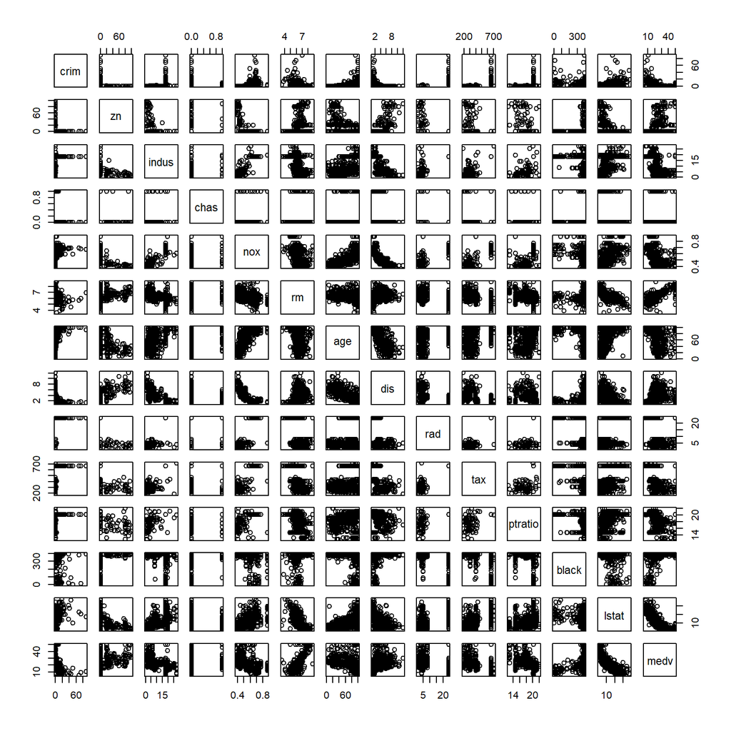

```r
library(corrplot)
library(tidyverse)

# plot matrix of the variables
pairs(Boston)
```

```r
# calculate the correlation matrix and round it
cor_matrix<-cor(Boston) %>% round(digits = 2)

# print the correlation matrix
cor_matrix
```

```
##          crim    zn indus  chas   nox    rm   age   dis   rad   tax ptratio
## crim     1.00 -0.20  0.41 -0.06  0.42 -0.22  0.35 -0.38  0.63  0.58    0.29
## zn      -0.20  1.00 -0.53 -0.04 -0.52  0.31 -0.57  0.66 -0.31 -0.31   -0.39
## indus    0.41 -0.53  1.00  0.06  0.76 -0.39  0.64 -0.71  0.60  0.72    0.38
## chas    -0.06 -0.04  0.06  1.00  0.09  0.09  0.09 -0.10 -0.01 -0.04   -0.12
## nox      0.42 -0.52  0.76  0.09  1.00 -0.30  0.73 -0.77  0.61  0.67    0.19
## rm      -0.22  0.31 -0.39  0.09 -0.30  1.00 -0.24  0.21 -0.21 -0.29   -0.36
## age      0.35 -0.57  0.64  0.09  0.73 -0.24  1.00 -0.75  0.46  0.51    0.26
## dis     -0.38  0.66 -0.71 -0.10 -0.77  0.21 -0.75  1.00 -0.49 -0.53   -0.23
## rad      0.63 -0.31  0.60 -0.01  0.61 -0.21  0.46 -0.49  1.00  0.91    0.46
## tax      0.58 -0.31  0.72 -0.04  0.67 -0.29  0.51 -0.53  0.91  1.00    0.46
## ptratio  0.29 -0.39  0.38 -0.12  0.19 -0.36  0.26 -0.23  0.46  0.46    1.00
## black   -0.39  0.18 -0.36  0.05 -0.38  0.13 -0.27  0.29 -0.44 -0.44   -0.18
## lstat    0.46 -0.41  0.60 -0.05  0.59 -0.61  0.60 -0.50  0.49  0.54    0.37
## medv    -0.39  0.36 -0.48  0.18 -0.43  0.70 -0.38  0.25 -0.38 -0.47   -0.51
##         black lstat  medv
## crim    -0.39  0.46 -0.39
## zn       0.18 -0.41  0.36
## indus   -0.36  0.60 -0.48
## chas     0.05 -0.05  0.18
## nox     -0.38  0.59 -0.43
## rm       0.13 -0.61  0.70
## age     -0.27  0.60 -0.38
## dis      0.29 -0.50  0.25
## rad     -0.44  0.49 -0.38
## tax     -0.44  0.54 -0.47
## ptratio -0.18  0.37 -0.51
## black    1.00 -0.37  0.33
## lstat   -0.37  1.00 -0.74
## medv     0.33 -0.74  1.00
```

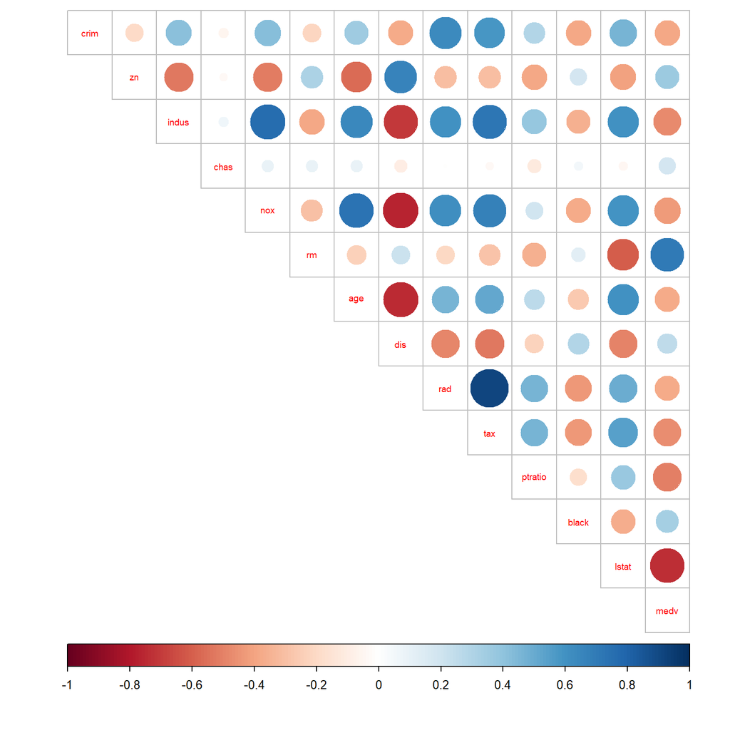

```r
# visualize the correlation matrix
corrplot(cor_matrix, method="circle", type="upper", cl.pos="b", tl.pos="d", tl.cex = 0.6)
```

Here, correlation (Pearson’s *r*) between variables is shown as an matrix and as a plot. We can observe highest correlations between

Specifically, **per capita crime rate by town (crim)** has

- moderate and positive relationship with access to radial highways ( *r* = 0.63) and property tax rate ( *r* = 0.58); and
- weak and negative relationship with **proportion of black populace** (black, *r* = -0.39) and **median house values** (medv, *r* = -0.39).

### Linear discrimination analysis (LDA)

Linear discriminant analysis produces results based on the assumptions that:

- variables are normally distributed (on condition of the classes)
- the normal distributions for each class share the same covariance matrix

Because of the assumptions, we need to standardize and scale our data before fitting the model. This can be done using R scale function, assigning scaled dataset to a new **boston_scaled** object.

```r
# center and standardize variables, and change the matrix to a data.frame
boston_scaled <- scale(Boston) %>% as.data.frame()

# summaries of the scaled variables
summary(boston_scaled)
```

```
##       crim                 zn               indus              chas
##  Min.   :-0.419367   Min.   :-0.48724   Min.   :-1.5563   Min.   :-0.2723
##  1st Qu.:-0.410563   1st Qu.:-0.48724   1st Qu.:-0.8668   1st Qu.:-0.2723
##  Median :-0.390280   Median :-0.48724   Median :-0.2109   Median :-0.2723
##  Mean   : 0.000000   Mean   : 0.00000   Mean   : 0.0000   Mean   : 0.0000
##  3rd Qu.: 0.007389   3rd Qu.: 0.04872   3rd Qu.: 1.0150   3rd Qu.:-0.2723
##  Max.   : 9.924110   Max.   : 3.80047   Max.   : 2.4202   Max.   : 3.6648
##       nox                rm               age               dis
##  Min.   :-1.4644   Min.   :-3.8764   Min.   :-2.3331   Min.   :-1.2658
##  1st Qu.:-0.9121   1st Qu.:-0.5681   1st Qu.:-0.8366   1st Qu.:-0.8049
##  Median :-0.1441   Median :-0.1084   Median : 0.3171   Median :-0.2790
##  Mean   : 0.0000   Mean   : 0.0000   Mean   : 0.0000   Mean   : 0.0000
##  3rd Qu.: 0.5981   3rd Qu.: 0.4823   3rd Qu.: 0.9059   3rd Qu.: 0.6617
##  Max.   : 2.7296   Max.   : 3.5515   Max.   : 1.1164   Max.   : 3.9566
##       rad               tax             ptratio            black
##  Min.   :-0.9819   Min.   :-1.3127   Min.   :-2.7047   Min.   :-3.9033
##  1st Qu.:-0.6373   1st Qu.:-0.7668   1st Qu.:-0.4876   1st Qu.: 0.2049
##  Median :-0.5225   Median :-0.4642   Median : 0.2746   Median : 0.3808
##  Mean   : 0.0000   Mean   : 0.0000   Mean   : 0.0000   Mean   : 0.0000
##  3rd Qu.: 1.6596   3rd Qu.: 1.5294   3rd Qu.: 0.8058   3rd Qu.: 0.4332
##  Max.   : 1.6596   Max.   : 1.7964   Max.   : 1.6372   Max.   : 0.4406
##      lstat              medv
##  Min.   :-1.5296   Min.   :-1.9063
##  1st Qu.:-0.7986   1st Qu.:-0.5989
##  Median :-0.1811   Median :-0.1449
##  Mean   : 0.0000   Mean   : 0.0000
##  3rd Qu.: 0.6024   3rd Qu.: 0.2683
##  Max.   : 3.5453   Max.   : 2.9865
```

Let’s now focus to Boston crime rate. For the purposes of LDA we need transform interval variable **crim** into a categorial variable **crime**. One way to go about this is to use crim quantiles as cut-off points (roughly equal sized bins) with the quantile function. Afterwards, we better substitute the old variable with the new one.

```r
# create a quantile vector of crim and print it
bins <- quantile(boston_scaled$crim)
bins
```

```
##           0%          25%          50%          75%         100%
## -0.419366929 -0.410563278 -0.390280295  0.007389247  9.924109610
```

```r
# create a categorical variable 'crime'; label break points from low to high:
crime <- cut(boston_scaled$crim, breaks = bins, labels =
               c("low", "med_low", "med_high", "high"), include.lowest = TRUE)

# look at the table of the new factor crime
table(crime)
```

```
## crime
##      low  med_low med_high     high
##      127      126      126      127
```

```r
# remove original crim from the dataset and add in the new categorical one:
boston_scaled <- dplyr::select(boston_scaled, -crim)
boston_scaled <- data.frame(boston_scaled, crime)
glimpse(boston_scaled)
```

```
## Rows: 506
## Columns: 14
## $ zn      <dbl> 0.28454827, -0.48724019, -0.48724019, -0.48724019, -0.48724019~
## $ indus   <dbl> -1.2866362, -0.5927944, -0.5927944, -1.3055857, -1.3055857, -1~
## $ chas    <dbl> -0.2723291, -0.2723291, -0.2723291, -0.2723291, -0.2723291, -0~
## $ nox     <dbl> -0.1440749, -0.7395304, -0.7395304, -0.8344581, -0.8344581, -0~
## $ rm      <dbl> 0.4132629, 0.1940824, 1.2814456, 1.0152978, 1.2273620, 0.20689~
## $ age     <dbl> -0.11989477, 0.36680343, -0.26554897, -0.80908783, -0.51067434~
## $ dis     <dbl> 0.1400749840, 0.5566090496, 0.5566090496, 1.0766711351, 1.0766~
## $ rad     <dbl> -0.9818712, -0.8670245, -0.8670245, -0.7521778, -0.7521778, -0~
## $ tax     <dbl> -0.6659492, -0.9863534, -0.9863534, -1.1050216, -1.1050216, -1~
## $ ptratio <dbl> -1.4575580, -0.3027945, -0.3027945, 0.1129203, 0.1129203, 0.11~
## $ black   <dbl> 0.4406159, 0.4406159, 0.3960351, 0.4157514, 0.4406159, 0.41016~
## $ lstat   <dbl> -1.07449897, -0.49195252, -1.20753241, -1.36017078, -1.0254866~
## $ medv    <dbl> 0.15952779, -0.10142392, 1.32293748, 1.18158864, 1.48603229, 0~
## $ crime   <fct> low, low, low, low, low, low, med_low, med_low, med_low, med_l~
```

```r
# assign 80% of Boston rows randomly to ind
ind <- sample(nrow(boston_scaled),  size = nrow(boston_scaled) * 0.8)

# create "train" set that consists of the sample selection ind
train <- boston_scaled[ind,]
dim(train)
```

```
## [1] 404  14
```

```r
# and a "test" set out of the remaining 20 % of rows, and remove crime variable:
test <- boston_scaled[-ind,]
dim(test)
```

```
## [1] 102  14
```

```r
# save the correct classes from test data
correct_classes <- test$crime

# remove the crime variable from test data
test <- dplyr::select(test, -crime)
dim(test)
```

```
## [1] 102  13
```

Train consists of 404 observations, and test of 102 observations and 13 variables.

Now we are ready to fit the LDA on the train set using lda() function. In our formula, we have crime (a multiclass variable) as our target, and all other variables as predictors. We will visualize our model in 2-dimensional bi-plot.

```r
# linear discriminant analysis
lda.fit <- lda(crime ~ ., data = train)
str(train)
```

```
## 'data.frame':    404 obs. of  14 variables:
##  $ zn     : num  -0.487 0.37 -0.487 -0.487 3.586 ...
##  $ indus  : num  -0.616 -1.045 1.015 1.231 -1.233 ...
##  $ chas   : num  -0.272 -0.272 -0.272 3.665 -0.272 ...
##  $ nox    : num  -0.921 0.797 1.366 2.73 -1.196 ...
##  $ rm     : num  -0.165 1.311 0.527 -1.255 2.232 ...
##  $ age    : num  -2.202 0.818 1.052 1.116 -1.257 ...
##  $ dis    : num  0.915 -0.886 -0.684 -1.175 0.628 ...
##  $ rad    : num  -0.752 -0.522 1.66 -0.522 -0.637 ...
##  $ tax    : num  -1.0398 -0.8558 1.5294 -0.0311 -1.0932 ...
##  $ ptratio: num  -0.257 -2.52 0.806 -1.735 -1.735 ...
##  $ black  : num  0.2924 0.3419 -0.0152 0.4406 0.3955 ...
##  $ lstat  : num  -0.958 -0.638 0.711 1.984 -1.238 ...
##  $ medv   : num  0.301 1.519 -0.797 -0.993 2.823 ...
##  $ crime  : Factor w/ 4 levels "low","med_low",..: 2 3 4 3 1 3 3 2 3 1 ...
```

```r
# print the lda.fit object
lda.fit
```

```
## Call:
## lda(crime ~ ., data = train)
##
## Prior probabilities of groups:
##       low   med_low  med_high      high
## 0.2524752 0.2425743 0.2500000 0.2549505
##
## Group means:
##                  zn      indus         chas        nox         rm        age
## low       1.1307412 -0.9520910 -0.117932980 -0.9079889  0.4468209 -0.9298046
## med_low  -0.1214720 -0.2487144  0.049066870 -0.5622762 -0.1119019 -0.2602927
## med_high -0.3836558  0.2144989  0.156464027  0.3451744  0.1081660  0.3831592
## high     -0.4872402  1.0170891 -0.004759149  1.0591525 -0.3860095  0.8166656
##                 dis        rad        tax    ptratio      black       lstat
## low       0.9293239 -0.6958804 -0.7240035 -0.5260488  0.3772788 -0.77150123
## med_low   0.3379645 -0.5494382 -0.4847985 -0.1067204  0.3117645 -0.10574115
## med_high -0.3685637 -0.3928554 -0.2776926 -0.1934921  0.1509593 -0.01641516
## high     -0.8555189  1.6384176  1.5142626  0.7811136 -0.7771867  0.88578994
##                 medv
## low       0.54306710
## med_low  -0.01310863
## med_high  0.18601051
## high     -0.69035983
##
## Coefficients of linear discriminants:
##                 LD1           LD2         LD3
## zn       0.12482867  0.9017012053 -0.86988536
## indus    0.05834245 -0.4163231264  0.22366785
## chas    -0.08877621 -0.0087770398  0.21757898
## nox      0.48845784 -0.5432874954 -1.66321929
## rm      -0.10098411 -0.1165521163 -0.08527685
## age      0.21310606 -0.2592968414  0.02563184
## dis     -0.06849537 -0.3682499059  0.21225355
## rad      3.02595246  0.9181180383  0.28591948
## tax     -0.12705054  0.0052136286  0.45414568
## ptratio  0.13748007  0.0002452809 -0.41521083
## black   -0.14962785 -0.0079371078  0.10795267
## lstat    0.22539628 -0.2266899253  0.31255125
## medv     0.19861350 -0.3736112465 -0.36690411
##
## Proportion of trace:
##    LD1    LD2    LD3
## 0.9377 0.0463 0.0160
```

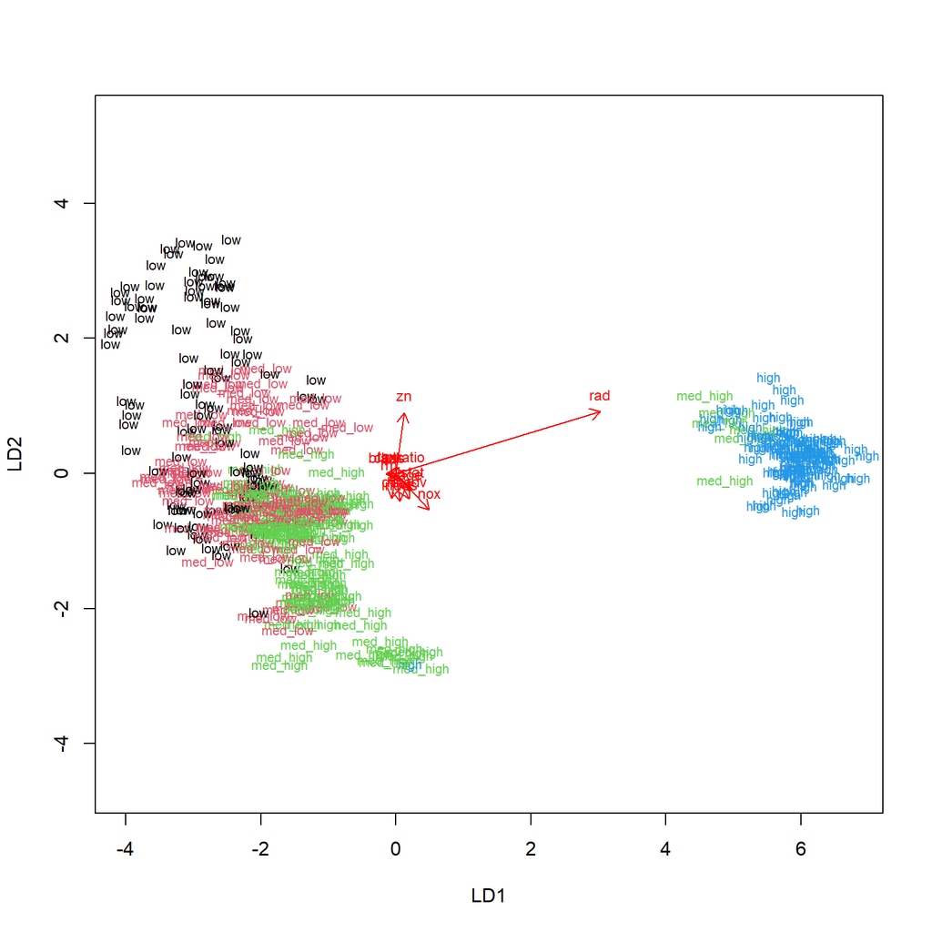

```r
# the function for lda biplot arrows
lda.arrows <- function(x, myscale = 1, arrow_heads = 0.1, color = "red", tex = 0.75, choices = c(1,2)){
  heads <- coef(x)
  arrows(x0 = 0, y0 = 0,
         x1 = myscale * heads[,choices[1]],
         y1 = myscale * heads[,choices[2]], col=color, length = arrow_heads)
  text(myscale * heads[,choices], labels = row.names(heads),
       cex = tex, col=color, pos=3)
}

# target classes as numeric
classes <- as.numeric(train$crime)

# plot the lda results
plot(lda.fit, dimen = 2, col = classes, pch = classes)

lda.arrows(lda.fit, myscale = 1)
```

**(NB! Every time document is knitted as html, test and train data sets are randomly sampled anew. This will alter the model and the prediction below, so that my interpretations may be wildly off. Sorry for the inconvenience)**

### Predict LDA

We can use predict() function with our test data set to see how accurately our model can predict our observations.

```r
# predict classes with test data
lda.pred <- predict(lda.fit, newdata = test)

# cross tabulate the results
corr_v_pred <- table(correct = correct_classes, predicted = lda.pred$class)
corr_v_pred
```

```
##           predicted
## correct    low med_low med_high high
##   low        6      16        3    0
##   med_low    4      18        6    0
##   med_high   0       8       17    0
##   high       0       0        0   24
```

```r
# display frequencies as row precentages
prop.table(corr_v_pred, 1) * 100
```

```
##           predicted
## correct          low   med_low  med_high      high
##   low       24.00000  64.00000  12.00000   0.00000
##   med_low   14.28571  64.28571  21.42857   0.00000
##   med_high   0.00000  32.00000  68.00000   0.00000
##   high       0.00000   0.00000   0.00000 100.00000
```

### Distance measures and k-clustering

```r
# load MASS and Boston
library(MASS)
data('Boston')
boston_scaled <- scale(Boston) %>% as.data.frame()

# euclidean distance matrix
dist_eu <- dist(Boston)

# look at the summary of the distances
summary(dist_eu)
```

```
##    Min. 1st Qu.  Median    Mean 3rd Qu.    Max.
##   1.119  85.624 170.539 226.315 371.950 626.047
```

```r
# manhattan distance matrix
dist_man <- dist(Boston, method = "manhattan")

# look at the summary of the distances
summary(dist_man)
```

```
##     Min.  1st Qu.   Median     Mean  3rd Qu.     Max.
##    2.016  149.145  279.505  342.899  509.707 1198.265
```

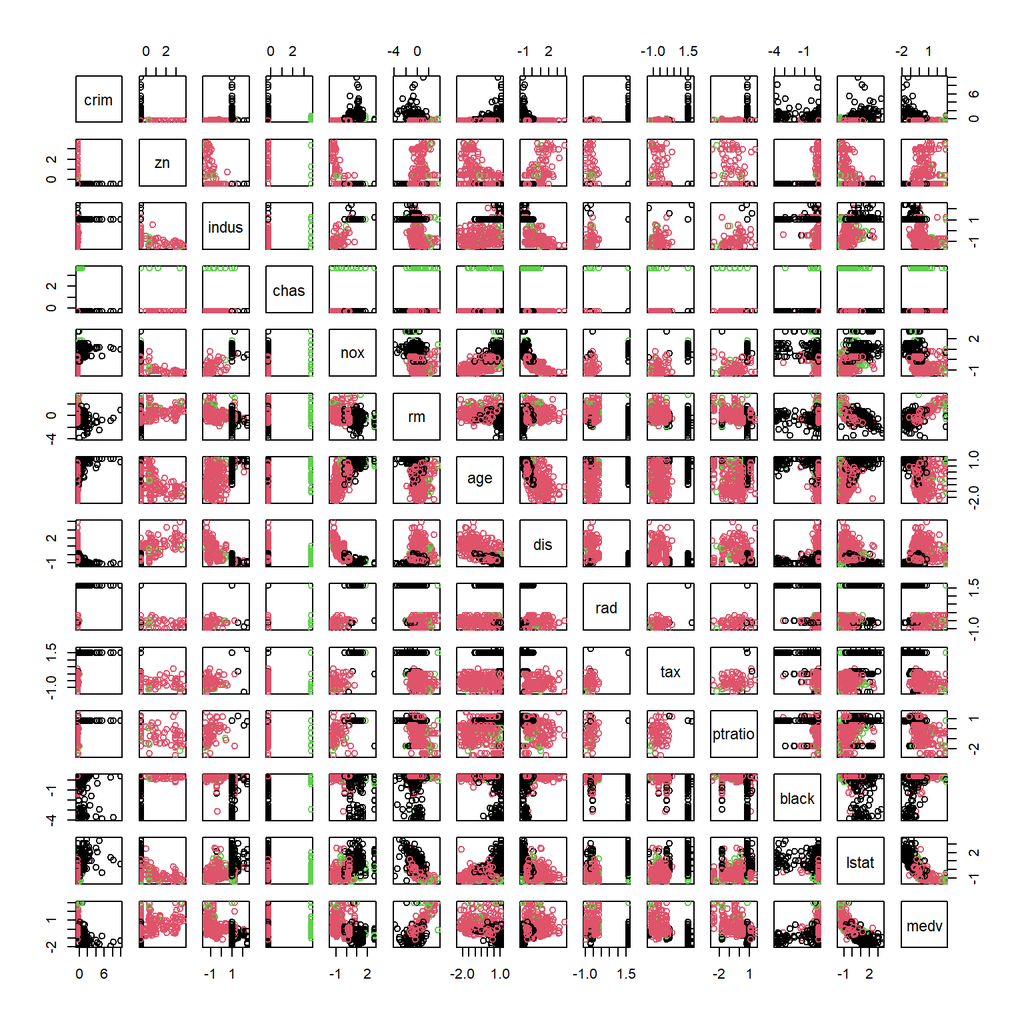

```r
# k-means clustering
km <-kmeans(boston_scaled, centers = 3)

# plot the Boston dataset with clusters
pairs(boston_scaled, col = km$cluster)
```

Above, we have randomly disriminated our dataset into three clusters, with no clear idea wheather or not this choice is optimal. To find such number, we will calculate total within sum of squares (TWCSS); in other words, search for a partition of our observations in boston_scaled into *k* groups that minimizes the within-group sum of squares (WGSS) over all variables:

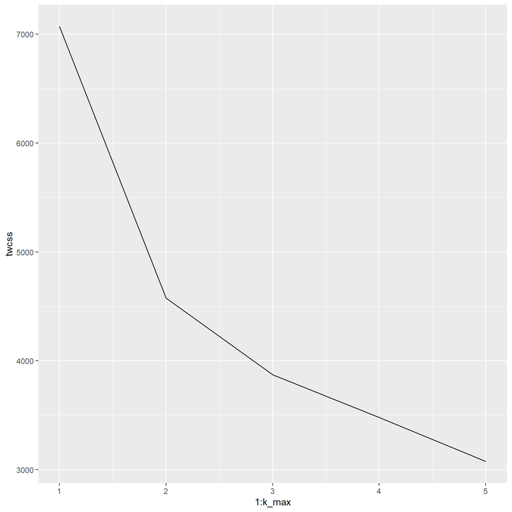

```r
# determine the number of clusters
k_max <- 5

# calculate the total within sum of squares
twcss <- sapply(1:k_max, function(k){kmeans(boston_scaled, k)$tot.withinss})

# visualize the results
qplot(x = 1:k_max, y = twcss, geom = 'line')
```

The line chart plots how TWCSS/WGSS behaves as number of clusters (in the x axis) changes. the optimal number of cluster is on the point Where TWCSS drops dramatically, which in our case is 2 (from over 7000 to little over 4500; more than next three drops combined)

Finally, using K-means clustering with two clusters, let’s plot variables pairs, colored by clusters for our scaled data set:

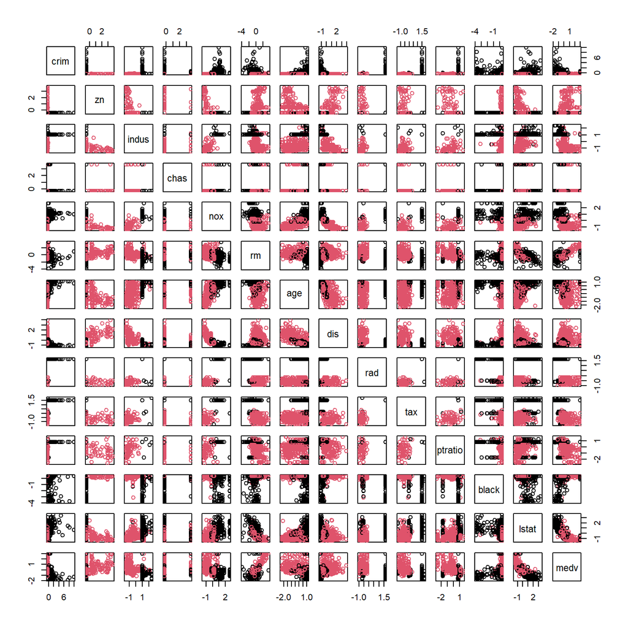

```r
# k-means clustering
km <-kmeans(boston_scaled, centers = 2)

# plot the Boston dataset with clusters
pairs(boston_scaled, col = km$cluster)
```

# Exercise 5, Week 5: Dimensionality reduction techniques

Dimensionality reduction techniques exercise is performed on previously merged “human” data set, read from GitHub repo. It consist of combined Human Development and Gender inequality data sets on country level. Description of original data can be found [here](http://hdr.undp.org/en/content/human-development-index-hdi) and [here](http://hdr.undp.org/sites/default/files/hdr2015_technical_notes.pdf), respectively.

```r
# Read human.csv
human <- read.table("https://raw.githubusercontent.com/tuohmas/IODS-project/master/data/human.csv",
                    header = T, sep = ";")
str(human)
```

```
## 'data.frame':    155 obs. of  8 variables:
##  $ edu2_f2m       : num  1.007 0.997 0.983 0.989 0.969 ...
##  $ lab_f2m        : num  0.891 0.819 0.825 0.884 0.829 ...
##  $ life_exp_birth : num  81.6 82.4 83 80.2 81.6 80.9 80.9 79.1 82 81.8 ...
##  $ edu_expected   : num  17.5 20.2 15.8 18.7 17.9 16.5 18.6 16.5 15.9 19.2 ...
##  $ gni_per_capita : int  64992 42261 56431 44025 45435 43919 39568 52947 42155 32689 ...
##  $ mat_mortality  : int  4 6 6 5 6 7 9 28 11 8 ...
##  $ adol_birth_rate: num  7.8 12.1 1.9 5.1 6.2 3.8 8.2 31 14.5 25.3 ...
##  $ repr           : num  39.6 30.5 28.5 38 36.9 36.9 19.9 19.4 28.2 31.4 ...
```

```r
summary(human)
```

```
##     edu2_f2m         lab_f2m       life_exp_birth   edu_expected
##  Min.   :0.1717   Min.   :0.1857   Min.   :49.00   Min.   : 5.40
##  1st Qu.:0.7264   1st Qu.:0.5984   1st Qu.:66.30   1st Qu.:11.25
##  Median :0.9375   Median :0.7535   Median :74.20   Median :13.50
##  Mean   :0.8529   Mean   :0.7074   Mean   :71.65   Mean   :13.18
##  3rd Qu.:0.9968   3rd Qu.:0.8535   3rd Qu.:77.25   3rd Qu.:15.20
##  Max.   :1.4967   Max.   :1.0380   Max.   :83.50   Max.   :20.20
##  gni_per_capita   mat_mortality    adol_birth_rate       repr
##  Min.   :   581   Min.   :   1.0   Min.   :  0.60   Min.   : 0.00
##  1st Qu.:  4198   1st Qu.:  11.5   1st Qu.: 12.65   1st Qu.:12.40
##  Median : 12040   Median :  49.0   Median : 33.60   Median :19.30
##  Mean   : 17628   Mean   : 149.1   Mean   : 47.16   Mean   :20.91
##  3rd Qu.: 24512   3rd Qu.: 190.0   3rd Qu.: 71.95   3rd Qu.:27.95
##  Max.   :123124   Max.   :1100.0   Max.   :204.80   Max.   :57.50
```

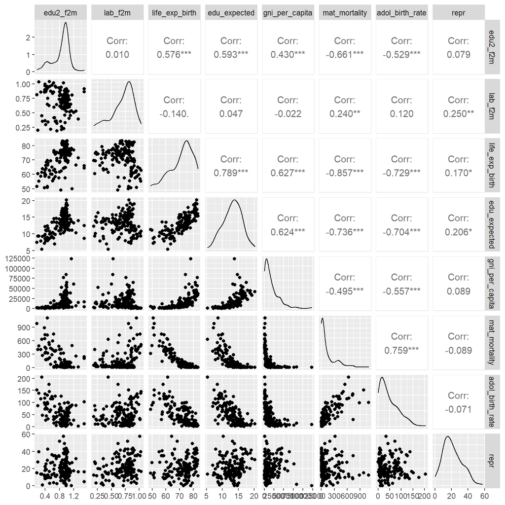

```r
# Access GGally
library(tidyverse)
library(GGally)

# visualize the 'human_' variables
GGally::ggpairs(human)
```

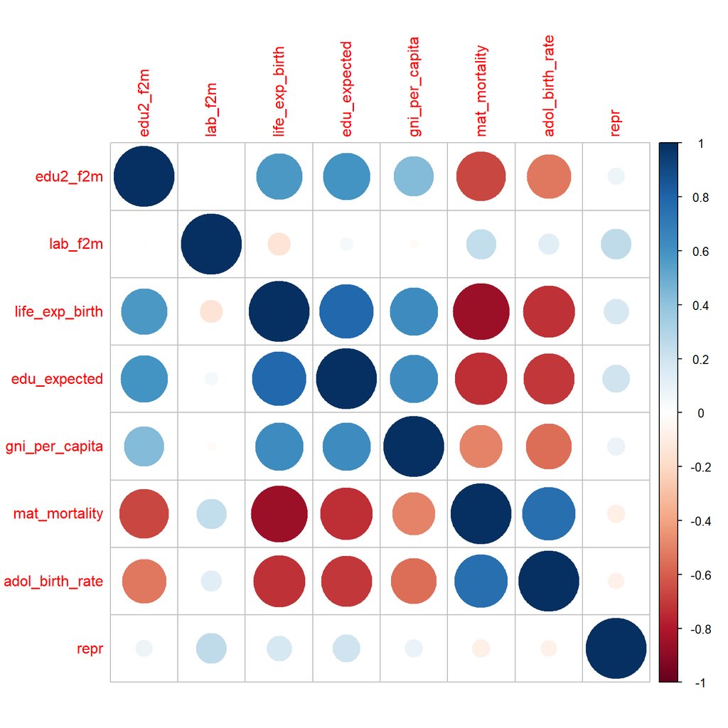

```r
# compute the correlation matrix and visualize it with corrplot
cor(human) %>% corrplot::corrplot()
```

## Principal Component Analysis

```r
# perform principal component analysis (with the SVD method)
pca_human <- prcomp(human)
summary(pca_human)
```

```
## Importance of components:
##                              PC1      PC2   PC3   PC4   PC5   PC6    PC7    PC8
## Standard deviation     1.854e+04 185.5219 25.19 11.45 3.766 1.566 0.1912 0.1591
## Proportion of Variance 9.999e-01   0.0001  0.00  0.00 0.000 0.000 0.0000 0.0000
## Cumulative Proportion  9.999e-01   1.0000  1.00  1.00 1.000 1.000 1.0000 1.0000
```

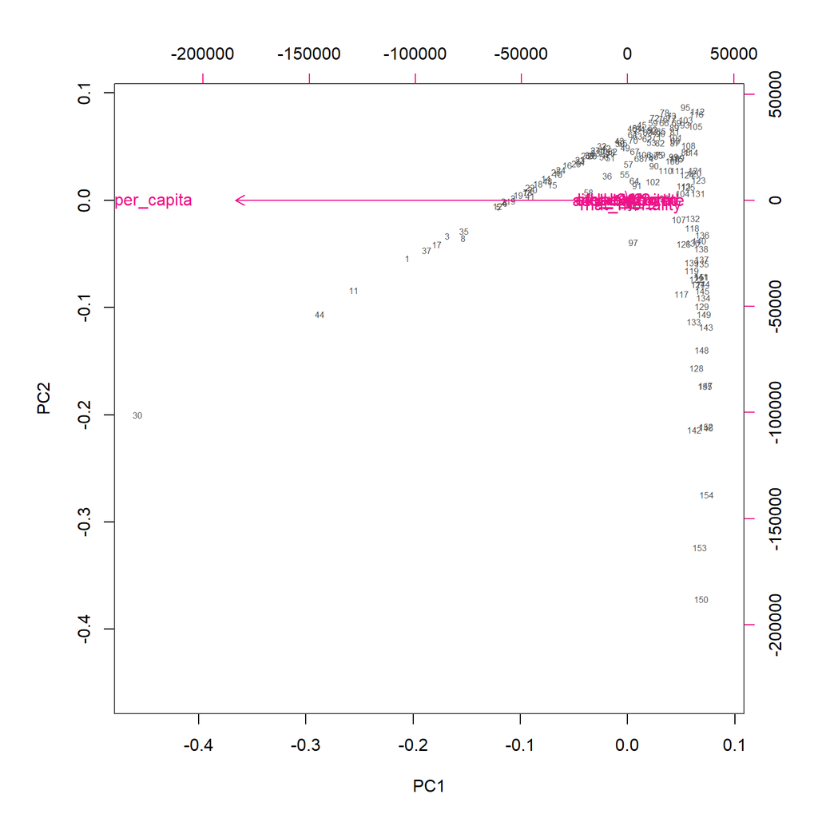

```r
# draw a biplot of the principal component representation and the original variables
biplot(pca_human, choices = 1:2, cex = c(0.5, 0,5),col = c("grey30", "deeppink2"))
```

```r
# Exploring the variances of human variables
library(psych)
describe(human)
```

```
##                 vars   n     mean       sd   median  trimmed      mad    min
## edu2_f2m           1 155     0.85     0.24     0.94     0.87     0.12   0.17
## lab_f2m            2 155     0.71     0.20     0.75     0.73     0.17   0.19
## life_exp_birth     3 155    71.65     8.33    74.20    72.40     7.56  49.00
## edu_expected       4 155    13.18     2.84    13.50    13.24     2.97   5.40
## gni_per_capita     5 155 17627.90 18543.85 12040.00 14552.58 13337.47 581.00
## mat_mortality      6 155   149.08   211.79    49.00   104.70    63.75   1.00
## adol_birth_rate    7 155    47.16    41.11    33.60    41.62    35.73   0.60
## repr               8 155    20.91    11.49    19.30    20.32    11.42   0.00
##                       max     range  skew kurtosis      se
## edu2_f2m             1.50      1.33 -0.76     0.55    0.02
## lab_f2m              1.04      0.85 -0.87     0.05    0.02
## life_exp_birth      83.50     34.50 -0.76    -0.15    0.67
## edu_expected        20.20     14.80 -0.20    -0.34    0.23
## gni_per_capita  123124.00 122543.00  2.14     6.83 1489.48
## mat_mortality     1100.00   1099.00  2.03     4.16   17.01
## adol_birth_rate    204.80    204.20  1.13     0.89    3.30
## repr                57.50     57.50  0.55    -0.10    0.92
```

```r
rev(sort(summarise_if(human, is.numeric, var)))
```

```
##   gni_per_capita mat_mortality adol_birth_rate     repr life_exp_birth
## 1      343874462      44854.83        1690.201 131.9683       69.42328
##   edu_expected  edu2_f2m    lab_f2m
## 1     8.067024 0.0583897 0.03951293
```

According to the summary, The first principal component is capturing unusually high proportion of the total variance in unstandardized human data, more than 99,99 per cent. This very skewed result is reflected also in the biplot:

How accurate is this pictur? We know that Pricipal Component Analysis is sensitive to the relative sclaing of original features, and is easily tipped off by variables that have larger variance compared to ones with smaller variance. We might deduce that GNI per capita dominates other, and indeed, its variance (343874462) is many orders of magnitudes higher than the next one, maternal mortality (44854.83).

Let’s therefore standardize (scale) our human data before performing any PCA.

```r
# standardize the variables
human_std <- scale(human)

# print out summaries of the standardized variables
summary(human_std)
```

```
##     edu2_f2m          lab_f2m        life_exp_birth     edu_expected
##  Min.   :-2.8189   Min.   :-2.6247   Min.   :-2.7188   Min.   :-2.7378
##  1st Qu.:-0.5233   1st Qu.:-0.5484   1st Qu.:-0.6425   1st Qu.:-0.6782
##  Median : 0.3503   Median : 0.2316   Median : 0.3056   Median : 0.1140
##  Mean   : 0.0000   Mean   : 0.0000   Mean   : 0.0000   Mean   : 0.0000
##  3rd Qu.: 0.5958   3rd Qu.: 0.7350   3rd Qu.: 0.6717   3rd Qu.: 0.7126
##  Max.   : 2.6646   Max.   : 1.6632   Max.   : 1.4218   Max.   : 2.4730
##  gni_per_capita    mat_mortality     adol_birth_rate        repr
##  Min.   :-0.9193   Min.   :-0.6992   Min.   :-1.1325   Min.   :-1.8203
##  1st Qu.:-0.7243   1st Qu.:-0.6496   1st Qu.:-0.8394   1st Qu.:-0.7409
##  Median :-0.3013   Median :-0.4726   Median :-0.3298   Median :-0.1403
##  Mean   : 0.0000   Mean   : 0.0000   Mean   : 0.0000   Mean   : 0.0000
##  3rd Qu.: 0.3712   3rd Qu.: 0.1932   3rd Qu.: 0.6030   3rd Qu.: 0.6127
##  Max.   : 5.6890   Max.   : 4.4899   Max.   : 3.8344   Max.   : 3.1850
```

```r
# perform principal component analysis (with the SVD method)
pca_human <- prcomp(human_std)

# create and print out a summary of pca_human
summary <- summary(pca_human)
summary
```

```
## Importance of components:
##                           PC1    PC2     PC3     PC4     PC5     PC6     PC7
## Standard deviation     2.0708 1.1397 0.87505 0.77886 0.66196 0.53631 0.45900
## Proportion of Variance 0.5361 0.1624 0.09571 0.07583 0.05477 0.03595 0.02634
## Cumulative Proportion  0.5361 0.6984 0.79413 0.86996 0.92473 0.96069 0.98702
##                            PC8
## Standard deviation     0.32224
## Proportion of Variance 0.01298
## Cumulative Proportion  1.00000
```

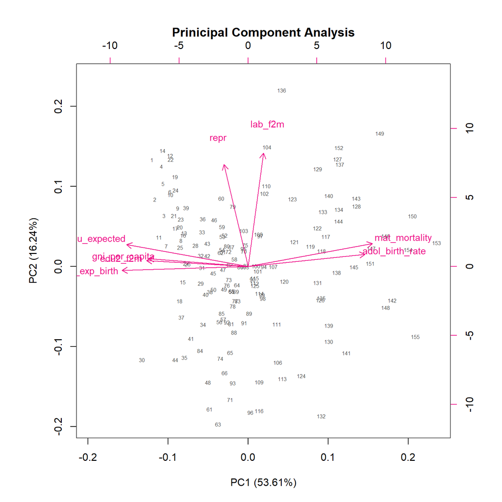

```r
# rounded percetanges of variance captured by each PC
pca_pr <- round(100*summary$importance[2, ], digits = 2)

# create object pc_lab to be used as axis labels
pc_lab <- paste0(names(pca_pr), " (", pca_pr, "%)")

# draw a biplot of the principal component representation and the original variables
biplot(pca_human, choices = 1:2, cex = c(0.5, 0.9),col = c("grey30", "deeppink2"), xlab = pc_lab[1], ylab = pc_lab[2], main = "Prinicipal Component Analysis")
```

For standardized human data, first PC captures much more believable proportion of total variance in data, about 54%, and together with PC2, about 70%. Including more than two PCs would benefit us only marginally as the total variance grows by less than ten per cent with each new dimensions we introduce.

Biplotting the first two principal components tells us that:

- PC1 is contributed by six variables (small angel between these features and PC1 axis): **(edu_expected)**, **(life_exp_birth)**, **(gni_per_capita)**, and **(edu2_f2m)**, that are highly positively correlated together, and **(mat_mortality)**, **(adol_birth_rate)**, that are highly and positively correlated to one another, and negatively correlated to the former four.
- PC2 is contributed by **female shares of parliamentary seats (repr)** and **female vs male labour force participation rate ratio (lab_f2m)**, that are minimally to other six variables (arrows at almost righ angles)
- Most of the variables have similarly large standard devations (arrow length)

There is no clear cut way to interpret our two PCs. However, it seems that [UN designated dimensions](http://hdr.undp.org/sites/default/files/hdr2015_technical_notes.pdf)“A decent standard of living”, “Health” and “Education” are better represented on PC1, whereas PC2 is primarily composed on indicators that measure “Empowerment” and “Labour market”.

## Multiple Correspondence Analysis

For Multiple Correspondence Analysis we will explore tea data set. For futher meta data, see ?tea.

```r
# column names to keep in the dataset
library(FactoMineR)

# load data set "tea"
data("tea")
glimpse(tea)
```

```
## Rows: 300
## Columns: 36
## $ breakfast        <fct> breakfast, breakfast, Not.breakfast, Not.breakfast, b~
## $ tea.time         <fct> Not.tea time, Not.tea time, tea time, Not.tea time, N~
## $ evening          <fct> Not.evening, Not.evening, evening, Not.evening, eveni~
## $ lunch            <fct> Not.lunch, Not.lunch, Not.lunch, Not.lunch, Not.lunch~
## $ dinner           <fct> Not.dinner, Not.dinner, dinner, dinner, Not.dinner, d~
## $ always           <fct> Not.always, Not.always, Not.always, Not.always, alway~
## $ home             <fct> home, home, home, home, home, home, home, home, home,~
## $ work             <fct> Not.work, Not.work, work, Not.work, Not.work, Not.wor~
## $ tearoom          <fct> Not.tearoom, Not.tearoom, Not.tearoom, Not.tearoom, N~
## $ friends          <fct> Not.friends, Not.friends, friends, Not.friends, Not.f~
## $ resto            <fct> Not.resto, Not.resto, resto, Not.resto, Not.resto, No~
## $ pub              <fct> Not.pub, Not.pub, Not.pub, Not.pub, Not.pub, Not.pub,~
## $ Tea              <fct> black, black, Earl Grey, Earl Grey, Earl Grey, Earl G~
```

[output cut: 23 more lines]

```r
keep_columns <- c("Tea", "How", "how", "sugar", "where", "lunch")

# select the 'keep_columns' to create a new dataset
tea_time <- dplyr::select(tea, one_of(keep_columns))

# look at the summaries and structure of the data
summary(tea_time)
```

```
##         Tea         How                      how           sugar
##  black    : 74   alone:195   tea bag           :170   No.sugar:155
##  Earl Grey:193   lemon: 33   tea bag+unpackaged: 94   sugar   :145
##  green    : 33   milk : 63   unpackaged        : 36
##                  other:  9
##                   where           lunch
##  chain store         :192   lunch    : 44
##  chain store+tea shop: 78   Not.lunch:256
##  tea shop            : 30
##
```

```r
str(tea_time)
```

```
## 'data.frame':    300 obs. of  6 variables:
##  $ Tea  : Factor w/ 3 levels "black","Earl Grey",..: 1 1 2 2 2 2 2 1 2 1 ...
##  $ How  : Factor w/ 4 levels "alone","lemon",..: 1 3 1 1 1 1 1 3 3 1 ...
##  $ how  : Factor w/ 3 levels "tea bag","tea bag+unpackaged",..: 1 1 1 1 1 1 1 1 2 2 ...
##  $ sugar: Factor w/ 2 levels "No.sugar","sugar": 2 1 1 2 1 1 1 1 1 1 ...
##  $ where: Factor w/ 3 levels "chain store",..: 1 1 1 1 1 1 1 1 2 2 ...
##  $ lunch: Factor w/ 2 levels "lunch","Not.lunch": 2 2 2 2 2 2 2 2 2 2 ...
```

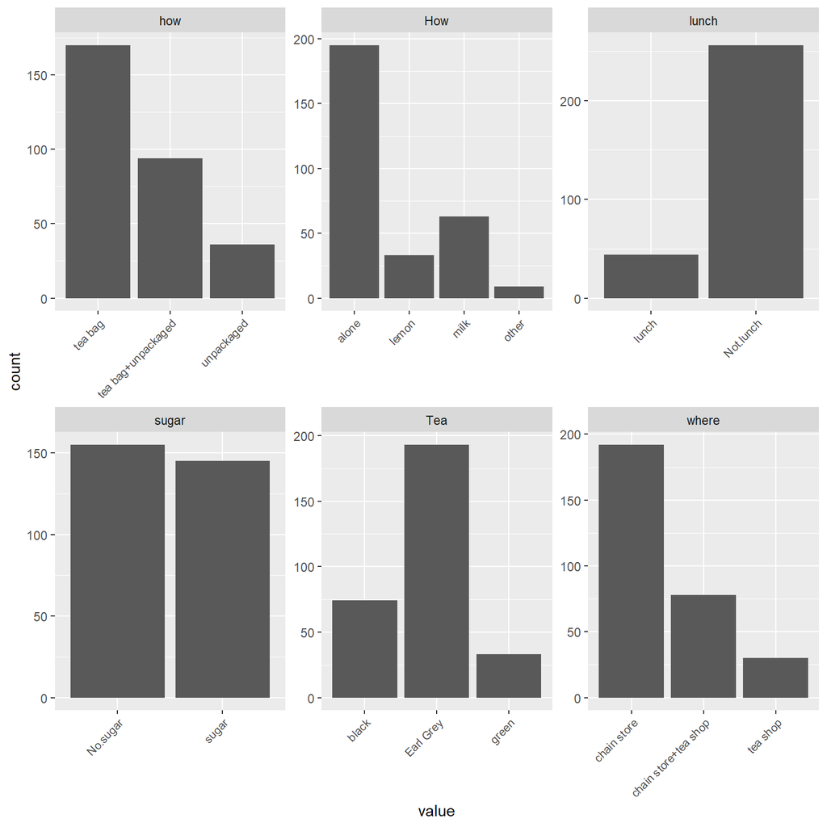

```r
# visualize the dataset
gather(tea_time) %>% ggplot(aes(value)) + facet_wrap("key", scales = "free") + geom_bar() + theme(axis.text.x = element_text(angle = 45, hjust = 1, size = 8))
```

```r
mca <- MCA(tea_time, graph = FALSE)

# summary of the model
summary(mca)
```

```
##
## Call:
## MCA(X = tea_time, graph = FALSE)
##
##
## Eigenvalues
##                        Dim.1   Dim.2   Dim.3   Dim.4   Dim.5   Dim.6   Dim.7
## Variance               0.279   0.261   0.219   0.189   0.177   0.156   0.144
## % of var.             15.238  14.232  11.964  10.333   9.667   8.519   7.841
## Cumulative % of var.  15.238  29.471  41.435  51.768  61.434  69.953  77.794
##                        Dim.8   Dim.9  Dim.10  Dim.11
## Variance               0.141   0.117   0.087   0.062
## % of var.              7.705   6.392   4.724   3.385
## Cumulative % of var.  85.500  91.891  96.615 100.000
##
## Individuals (the 10 first)
##                       Dim.1    ctr   cos2    Dim.2    ctr   cos2    Dim.3
## 1                  | -0.298  0.106  0.086 | -0.328  0.137  0.105 | -0.327
## 2                  | -0.237  0.067  0.036 | -0.136  0.024  0.012 | -0.695
## 3                  | -0.369  0.162  0.231 | -0.300  0.115  0.153 | -0.202
## 4                  | -0.530  0.335  0.460 | -0.318  0.129  0.166 |  0.211
## 5                  | -0.369  0.162  0.231 | -0.300  0.115  0.153 | -0.202
## 6                  | -0.369  0.162  0.231 | -0.300  0.115  0.153 | -0.202
## 7                  | -0.369  0.162  0.231 | -0.300  0.115  0.153 | -0.202
## 8                  | -0.237  0.067  0.036 | -0.136  0.024  0.012 | -0.695
## 9                  |  0.143  0.024  0.012 |  0.871  0.969  0.435 | -0.067
## 10                 |  0.476  0.271  0.140 |  0.687  0.604  0.291 | -0.650
##                       ctr   cos2
## 1                   0.163  0.104 |
## 2                   0.735  0.314 |
## 3                   0.062  0.069 |
## 4                   0.068  0.073 |
## 5                   0.062  0.069 |
## 6                   0.062  0.069 |
## 7                   0.062  0.069 |
## 8                   0.735  0.314 |
## 9                   0.007  0.003 |
## 10                  0.643  0.261 |
##
## Categories (the 10 first)
```

[output cut: 16 more lines]

```
## lemon                3.226 |   1.329  14.771   0.218   8.081 |
## milk                 2.422 |   0.013   0.003   0.000   0.116 |
## other                5.534 |  -2.524  14.526   0.197  -7.676 |
## tea bag             -6.941 |  -0.065   0.183   0.006  -1.287 |
## tea bag+unpackaged  11.956 |   0.019   0.009   0.000   0.226 |
## unpackaged          -6.482 |   0.257   0.602   0.009   1.640 |
##
## Categorical variables (eta2)
##                      Dim.1 Dim.2 Dim.3
## Tea                | 0.126 0.108 0.410 |
## How                | 0.076 0.190 0.394 |
## how                | 0.708 0.522 0.010 |
## sugar              | 0.065 0.001 0.336 |
## where              | 0.702 0.681 0.055 |
## lunch              | 0.000 0.064 0.111 |
```

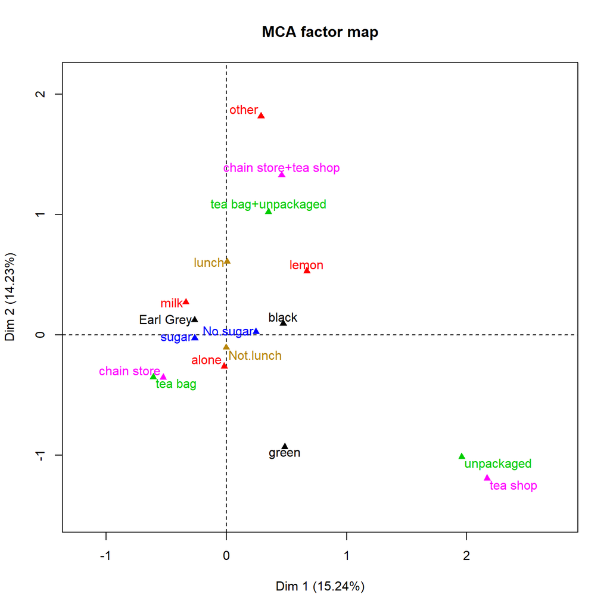

```r
# visualize MCA
plot(mca, invisible=c("ind"), habillage = "quali", graph.type = "classic")
```

Data is visualised on first two dimensions that capture 29.4% of its total variance.

From the biplot we see that:

- A cluster of names and lables, including **chain store**, **tea bag**; **Not.lunch**, **alone**; and **milk**, **sugar**, and **Earl Gray** are clumped to the centre, and similir with one another (close distances)
- **green** and **other** are not similar to any other label or name (great distances)

# Exercise 6, Week 6: Analysis of longitudinal data

```r
BPRS <- read.table("https://raw.githubusercontent.com/KimmoVehkalahti/MABS/master/Examples/data/BPRS.txt",
                   sep  =" ", header = T)

BPRSL <- read.table("https://raw.githubusercontent.com/tuohmas/IODS-project/master/data/bprsl.csv",
                    sep = ";", header = T)
RATSL <- read.table("https://raw.githubusercontent.com/tuohmas/IODS-project/master/data/ratsl.csv",
                    sep = ";", header = T)

library(tidyverse)

# Turn categorical variables to factors
BPRSL$treatment <- BPRSL$treatment %>% factor()
BPRSL$subject <- BPRSL$subject %>% factor()

RATSL$ID <- RATSL$ID %>% factor()
RATSL$Group <- RATSL$Group %>% factor()

# Glimpse data
glimpse(BPRSL)
```

```
## Rows: 360
## Columns: 5
## $ treatment <fct> 1, 1, 1, 1, 1, 1, 1, 1, 1, 1, 1, 1, 1, 1, 1, 1, 1, 1, 1, 1, ~
## $ subject   <fct> 1, 2, 3, 4, 5, 6, 7, 8, 9, 10, 11, 12, 13, 14, 15, 16, 17, 1~
## $ weeks     <chr> "week0", "week0", "week0", "week0", "week0", "week0", "week0~
## $ bprs      <int> 42, 58, 54, 55, 72, 48, 71, 30, 41, 57, 30, 55, 36, 38, 66, ~
## $ week      <int> 0, 0, 0, 0, 0, 0, 0, 0, 0, 0, 0, 0, 0, 0, 0, 0, 0, 0, 0, 0, ~
```

```r
glimpse(RATSL)
```

```
## Rows: 176
## Columns: 5
## $ ID     <fct> 1, 2, 3, 4, 5, 6, 7, 8, 9, 10, 11, 12, 13, 14, 15, 16, 1, 2, 3,~
## $ Group  <fct> 1, 1, 1, 1, 1, 1, 1, 1, 2, 2, 2, 2, 3, 3, 3, 3, 1, 1, 1, 1, 1, ~
## $ WD     <chr> "WD1", "WD1", "WD1", "WD1", "WD1", "WD1", "WD1", "WD1", "WD1", ~
## $ Weight <int> 240, 225, 245, 260, 255, 260, 275, 245, 410, 405, 445, 555, 470~
## $ Time   <int> 1, 1, 1, 1, 1, 1, 1, 1, 1, 1, 1, 1, 1, 1, 1, 1, 8, 8, 8, 8, 8, ~
```

## Analysis of BPRS data

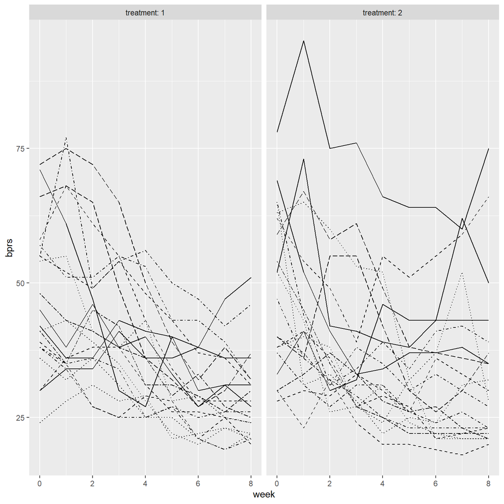

```r
library(ggplot2)

# BPRSL individuals on the plot
ggplot(BPRSL, aes(x = week, y = bprs, linetype = subject)) +
  geom_line() +
  scale_linetype_manual(values = rep(1:10, times=4)) +
  facet_grid(. ~ treatment, labeller = label_both) +
  theme(legend.position = "none") +
  scale_y_continuous(limits = c(min(BPRSL$bprs), max(BPRSL$bprs)))
```

To account for “tracking” (individuals who have higher BPRS values at the beginning tend to have higher values throughout the study), we will standardize data by subtrackting every observation by its group mean and dividing that the corresponding standard deviation.

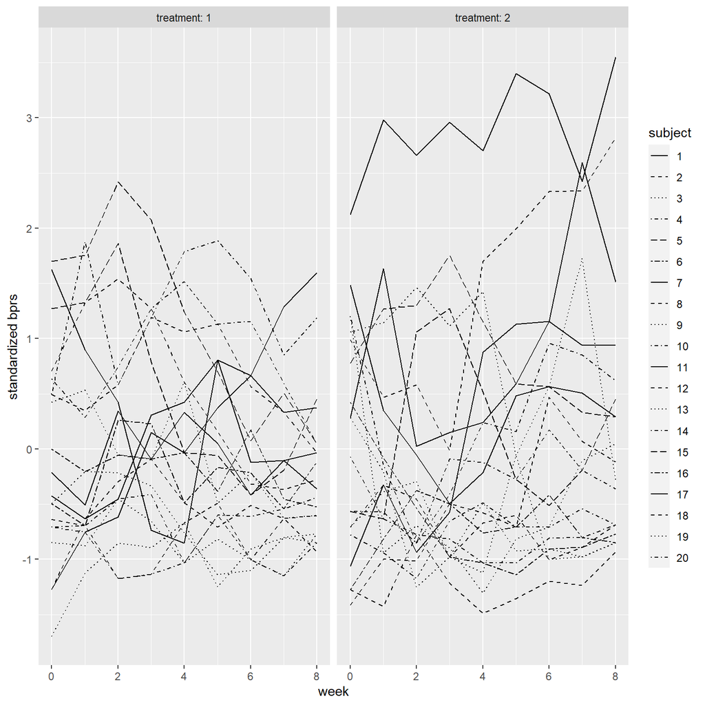

```r
# Create standardized object BPRSL
BPRSL <- BPRSL %>%
  group_by(week) %>%
  mutate(stdbprs = (bprs - mean(bprs))/sd(bprs)) %>%
  ungroup()

# Plot again with the standardised bprs
ggplot(BPRSL, aes(x = week, y = stdbprs, linetype = subject)) +
  geom_line() +
  scale_linetype_manual(values = rep(1:10, times=4)) +
  facet_grid(. ~ treatment, labeller = label_both) +
  scale_y_continuous(name = "standardized bprs")
```

## Mean profiles and mean differences

Let’s create mean profiles of our two treatment groups (summarising BPRSL means) by group weekly).

```r
# There are 20 subject per group
n <- 20

# Summarize data with mean and standard error of bprs by treatment and week
BPRSS <- BPRSL %>%
  group_by(treatment, week) %>%
  summarise(mean = mean(bprs), se = sd(bprs)/sqrt(n)) %>%
  ungroup()

# Glimpse the data
glimpse(BPRSS)
```

```
## Rows: 18
## Columns: 4
## $ treatment <fct> 1, 1, 1, 1, 1, 1, 1, 1, 1, 2, 2, 2, 2, 2, 2, 2, 2, 2
## $ week      <int> 0, 1, 2, 3, 4, 5, 6, 7, 8, 0, 1, 2, 3, 4, 5, 6, 7, 8
## $ mean      <dbl> 47.00, 46.80, 43.55, 40.90, 36.60, 32.70, 29.70, 29.80, 29.3~
## $ se        <dbl> 3.041814, 3.470629, 2.685708, 2.511971, 2.186562, 1.741294, ~
```

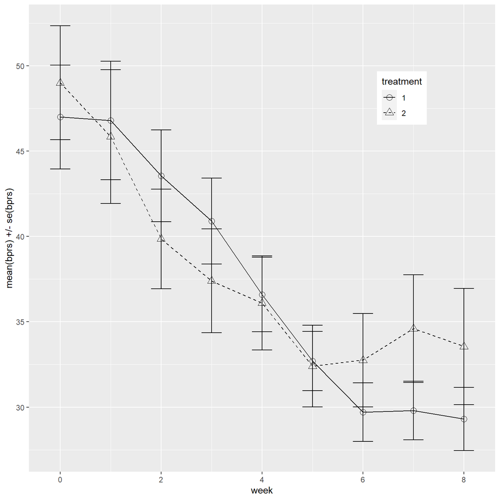

```r
# Plot the mean profiles
ggplot(BPRSS, aes(x = week, y = mean, linetype = treatment, shape = treatment)) +
  geom_line() +
  scale_linetype_manual(values = c(1,2)) +
  geom_point(size=3) +
  scale_shape_manual(values = c(1,2)) +
  geom_errorbar(aes(ymin=mean-se, ymax=mean+se, linetype="1"), width=0.4) +
  theme(legend.position = c(0.8,0.8)) +
  scale_y_continuous(name = "mean(bprs) +/- se(bprs)")
```

Standard errors notwhistanding, a clear downward pattern appears for both groups that was previously unnoticeable. From here alone we cannot clearly determine which group, if any shows tendency for lower scores: the lines intersersect twice.

A simple boxplot can tell us a better story.

```r
# Create a summary data by treatment and subject with mean as the summary var
BPRSL8S <- BPRSL %>%
  filter(week > 0) %>% # ignoring the baseline
  group_by(treatment, subject) %>%
  summarise(mean=mean(bprs)) %>%
  ungroup()

# Glimpse the data
glimpse(BPRSL8S)
```

```
## Rows: 40
## Columns: 3
## $ treatment <fct> 1, 1, 1, 1, 1, 1, 1, 1, 1, 1, 1, 1, 1, 1, 1, 1, 1, 1, 1, 1, ~
## $ subject   <fct> 1, 2, 3, 4, 5, 6, 7, 8, 9, 10, 11, 12, 13, 14, 15, 16, 17, 1~
## $ mean      <dbl> 41.500, 43.125, 35.375, 52.625, 50.375, 34.000, 37.125, 30.5~
```

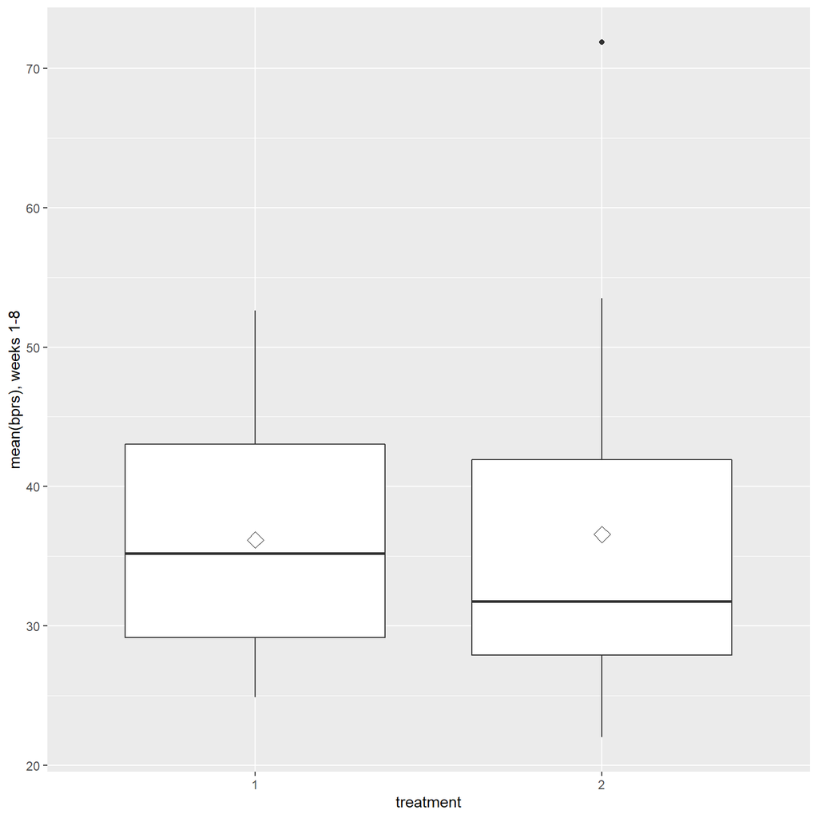

```r
# Draw a boxplot of the mean versus treatment
ggplot(BPRSL8S, aes(x = treatment, y = mean)) +
  geom_boxplot() +
  stat_summary(fun.y = "mean", geom = "point", shape=23, size=4, fill = "white") +
  scale_y_continuous(name = "mean(bprs), weeks 1-8")
```

The plot shows very little difference between treatment groups, although group 2 median and 25. percentage points are both slightly lower than is counterpart’s.

We also seem to have a single outlier we want to get rid of. Let’s investigate if this in fact the sole execption, and then filter the data set so to remove it.

```r
# Locate outliers
BPRSL8S[rev(order(BPRSL8S$mean)), ] %>% head(n = 5)
```

```
## # A tibble: 5 x 3
##   treatment subject  mean
##   <fct>     <fct>   <dbl>
## 1 2         11       71.9
## 2 2         8        53.5
## 3 1         4        52.6
## 4 1         5        50.4
## 5 2         1        48.5
```

```r
# Filter out the single outlier by filtering out means greater than 53.5:
BPRSL8S1 <- BPRSL8S %>% filter(mean < 54)

# See how many observations were removed
nrow(BPRSL8S1) - nrow(BPRSL8S)
```

```
## [1] -1
```

To investigate possible differences even further in order to attach them with a formal test result and confidence interval, let’s run t-test with the null hypothsis that the difference in means is zero.

```r
# Perform a two-sample t-test
t.test(mean ~ treatment, data = BPRSL8S1, var.equal = TRUE)
```

```
##
##  Two Sample t-test
##
## data:  mean by treatment
## t = 0.52095, df = 37, p-value = 0.6055
## alternative hypothesis: true difference in means between group 1 and group 2 is not equal to 0
## 95 percent confidence interval:
##  -4.232480  7.162085
## sample estimates:
## mean in group 1 mean in group 2
##        36.16875        34.70395
```

t-test shows no statistically significant difference between bprs means between groups 1 and 2 overall ( *p* = 0.61). The 95% confidence interval is wide and includes zero, driving this point home even harder.

### Analysis of Covariance of the BPRS Data

Baseline measurements of the outcome variable in a longitudinal study are often correlated with the chosen summary measure and using such measures in the analysis can often lead to substantial gains in precision when used ap- propriately as a covariate in an analysis of covariance.

To calculate this, we might run analysis of variance between groups pre- and post-treatment. we can do this with anova() function for fitted model object (fit), where mean is the target variable and baseline (measurments pre-treatment) and treatment are explanatory variables.

```r
# Add the baseline from the original data as a new variable to the summary data
BPRSL8S2 <- BPRSL8S %>%
  mutate(baseline = BPRS$week0)

# Fit the linear model with the mean as the response
fit <- lm(mean ~ baseline + treatment, data = BPRSL8S2)

# Compute the analysis of variance table for the fitted model with anova()
anova(fit)
```

```
## Analysis of Variance Table
##
## Response: mean
##           Df  Sum Sq Mean Sq F value    Pr(>F)
## baseline   1 1868.07 1868.07 30.1437 3.077e-06 ***
## treatment  1    3.45    3.45  0.0557    0.8148
## Residuals 37 2292.97   61.97
## ---
## Signif. codes:  0 '***' 0.001 '**' 0.01 '*' 0.05 '.' 0.1 ' ' 1
```

Our two-way ANOVA tests a null-hypothesis that there is no difference in means pre- and post-treatment. We see that the baseline BPRS is strongly related to the BPRS values taken after treatment has begun, but there is still no evidence of a treatment difference even after conditioning on the baseline value.

## Analysis of RATS data

To begin, we will plot the data, identifying the observations in each group but ignoring the longitudinal nature of the data (i.e., assume that all the observations are independent from one another).

Additionally, we explore whether there is a measurable relationship between body weight and time and the group by fitting the into linear regression model with former as a target variable and the two latter as explanatory variables.

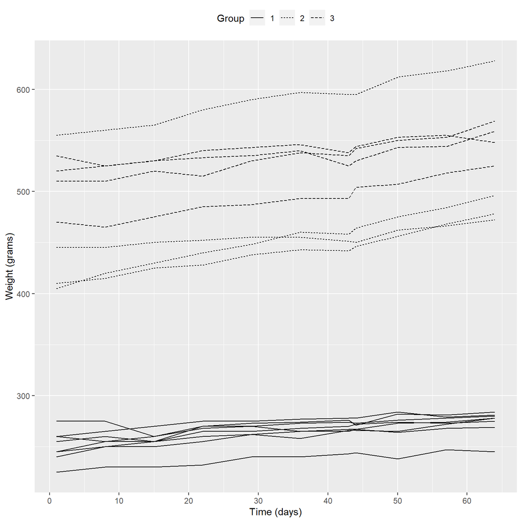

```r
# plot individual rat's growth profiles
ggplot(RATSL, aes(x = Time, y = Weight, group = ID)) +
  geom_line(aes(linetype = Group)) +
  scale_x_continuous(name = "Time (days)", breaks = seq(0, 60, 10)) +
  scale_y_continuous(name = "Weight (grams)") +
  theme(legend.position = "top")
```

```r
# create a regression model RATS_reg
RATS_reg <- lm(Weight ~ Time + Group, data = RATSL)

# print out a summary of the model
summary(RATS_reg)
```

```
##
## Call:
## lm(formula = Weight ~ Time + Group, data = RATSL)
##
## Residuals:
##     Min      1Q  Median      3Q     Max
## -60.643 -24.017   0.697  10.837 125.459
##
## Coefficients:
##             Estimate Std. Error t value Pr(>|t|)
## (Intercept) 244.0689     5.7725  42.281  < 2e-16 ***
## Time          0.5857     0.1331   4.402 1.88e-05 ***
## Group2      220.9886     6.3402  34.855  < 2e-16 ***
## Group3      262.0795     6.3402  41.336  < 2e-16 ***
## ---
## Signif. codes:  0 '***' 0.001 '**' 0.01 '*' 0.05 '.' 0.1 ' ' 1
##
## Residual standard error: 34.34 on 172 degrees of freedom
## Multiple R-squared:  0.9283, Adjusted R-squared:  0.9271
## F-statistic: 742.6 on 3 and 172 DF,  p-value: < 2.2e-16
```

A clear difference in rat body weight between Group 1 and other two groups. This difference is also measurable, with very slim chance to be accidental. In addition the regression on time is also highly significant.

### Fitting Linear Mixed Models to the Rat Data

Taking into account the longitudinal nature of the data, let’s fit a regression model

```r
library(lme4)

# Create a random intercept model
RATS_ref <- lmer(Weight ~ Time + Group + (1 | ID), data = RATSL, REML = FALSE)

# Print the summary of the model
summary(RATS_ref)
```

```
## Linear mixed model fit by maximum likelihood  ['lmerMod']
## Formula: Weight ~ Time + Group + (1 | ID)
##    Data: RATSL
##
##      AIC      BIC   logLik deviance df.resid
##   1333.2   1352.2   -660.6   1321.2      170
##
## Scaled residuals:
##     Min      1Q  Median      3Q     Max
## -3.5386 -0.5581 -0.0494  0.5693  3.0990
##
## Random effects:
##  Groups   Name        Variance Std.Dev.
##  ID       (Intercept) 1085.92  32.953
##  Residual               66.44   8.151
## Number of obs: 176, groups:  ID, 16
##
## Fixed effects:
##              Estimate Std. Error t value
## (Intercept) 244.06890   11.73107   20.80
## Time          0.58568    0.03158   18.54
## Group2      220.98864   20.23577   10.92
## Group3      262.07955   20.23577   12.95
##
## Correlation of Fixed Effects:
##        (Intr) Time   Group2
## Time   -0.090
## Group2 -0.575  0.000
## Group3 -0.575  0.000  0.333
```

```r
# create a random intercept and random slope model
RATS_ref1 <- lmer(Weight ~ Time + Group + (Time | ID), data = RATSL, REML = FALSE)

# print a summary of the model
summary(RATS_ref1)
```

```
## Linear mixed model fit by maximum likelihood  ['lmerMod']
## Formula: Weight ~ Time + Group + (Time | ID)
##    Data: RATSL
##
##      AIC      BIC   logLik deviance df.resid
##   1194.2   1219.6   -589.1   1178.2      168
##
## Scaled residuals:
##     Min      1Q  Median      3Q     Max
## -3.2259 -0.4322  0.0555  0.5637  2.8825
##
## Random effects:
##  Groups   Name        Variance  Std.Dev. Corr
##  ID       (Intercept) 1139.2004 33.7520
##           Time           0.1122  0.3349  -0.22
##  Residual               19.7479  4.4439
## Number of obs: 176, groups:  ID, 16
##
## Fixed effects:
##              Estimate Std. Error t value
## (Intercept) 246.46821   11.80888  20.871
## Time          0.58568    0.08548   6.852
## Group2      214.55803   20.16986  10.638
## Group3      258.91288   20.16986  12.837
##
## Correlation of Fixed Effects:
##        (Intr) Time   Group2
## Time   -0.166
## Group2 -0.569  0.000
## Group3 -0.569  0.000  0.333
## optimizer (nloptwrap) convergence code: 0 (OK)
## Model failed to converge with max|grad| = 0.0028726 (tol = 0.002, component 1)
```

```r
# perform an ANOVA test on the two models
anova(RATS_ref1, RATS_ref)
```

```
## Data: RATSL
## Models:
## RATS_ref: Weight ~ Time + Group + (1 | ID)
## RATS_ref1: Weight ~ Time + Group + (Time | ID)
##           npar    AIC    BIC  logLik deviance  Chisq Df Pr(>Chisq)
## RATS_ref     6 1333.2 1352.2 -660.58   1321.2
## RATS_ref1    8 1194.2 1219.6 -589.11   1178.2 142.94  2  < 2.2e-16 ***
## ---
## Signif. codes:  0 '***' 0.001 '**' 0.01 '*' 0.05 '.' 0.1 ' ' 1
```

```r
# create a random intercept and random slope model with the interaction
RATS_ref2 <- lmer(Weight ~ Time + Group + (Time | ID) + (Time * Group), data = RATSL, REML = FALSE)

# print a summary of the model
summary(RATS_ref2)
```

```
## Linear mixed model fit by maximum likelihood  ['lmerMod']
## Formula: Weight ~ Time + Group + (Time | ID) + (Time * Group)
##    Data: RATSL
##
##      AIC      BIC   logLik deviance df.resid
##   1185.9   1217.6   -582.9   1165.9      166
##
## Scaled residuals:
##     Min      1Q  Median      3Q     Max
## -3.2667 -0.4249  0.0726  0.6034  2.7511
##
## Random effects:
##  Groups   Name        Variance  Std.Dev. Corr
##  ID       (Intercept) 1.106e+03 33.2534
##           Time        4.925e-02  0.2219  -0.15
##  Residual             1.975e+01  4.4439
## Number of obs: 176, groups:  ID, 16
##
## Fixed effects:
##              Estimate Std. Error t value
## (Intercept) 251.65165   11.79473  21.336
## Time          0.35964    0.08215   4.378
## Group2      200.66549   20.42907   9.823
## Group3      252.07168   20.42907  12.339
## Time:Group2   0.60584    0.14229   4.258
## Time:Group3   0.29834    0.14229   2.097
##
## Correlation of Fixed Effects:
##             (Intr) Time   Group2 Group3 Tm:Gr2
## Time        -0.160
## Group2      -0.577  0.092
## Group3      -0.577  0.092  0.333
## Time:Group2  0.092 -0.577 -0.160 -0.053
## Time:Group3  0.092 -0.577 -0.053 -0.160  0.333
## optimizer (nloptwrap) convergence code: 0 (OK)
## Model failed to converge with max|grad| = 0.00504145 (tol = 0.002, component 1)
```

```r
# perform an ANOVA test on the two models
anova(RATS_ref2, RATS_ref1)
```

```
## Data: RATSL
## Models:
## RATS_ref1: Weight ~ Time + Group + (Time | ID)
## RATS_ref2: Weight ~ Time + Group + (Time | ID) + (Time * Group)
##           npar    AIC    BIC  logLik deviance  Chisq Df Pr(>Chisq)
## RATS_ref1    8 1194.2 1219.6 -589.11   1178.2
## RATS_ref2   10 1185.9 1217.6 -582.93   1165.9 12.361  2    0.00207 **
## ---
## Signif. codes:  0 '***' 0.001 '**' 0.01 '*' 0.05 '.' 0.1 ' ' 1
```

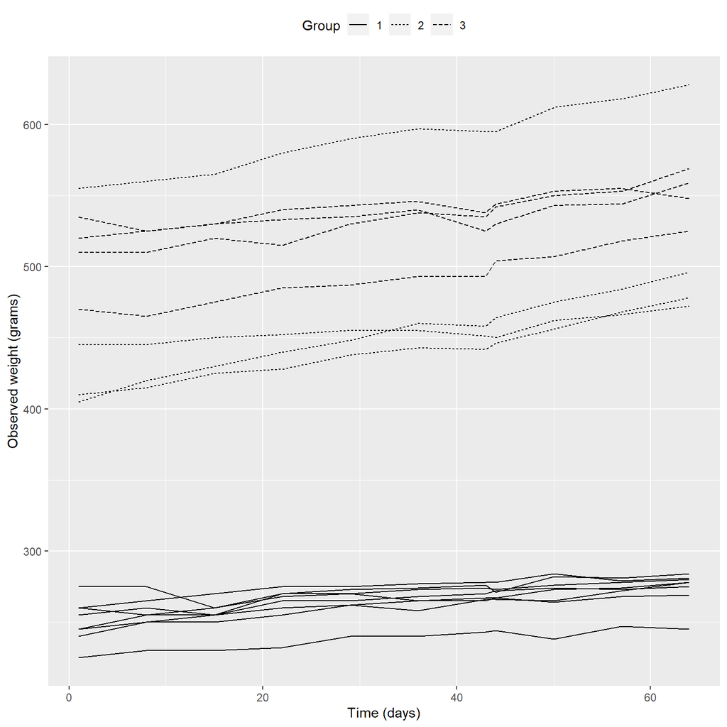

```r
# draw the plot of RATSL with the observed Weight values
ggplot(RATSL, aes(x = Time, y = Weight, group = ID)) +
  geom_line(aes(linetype = Group)) +
  scale_x_continuous(name = "Time (days)", breaks = seq(0, 60, 20)) +
  scale_y_continuous(name = "Observed weight (grams)") +
  theme(legend.position = "top")
```

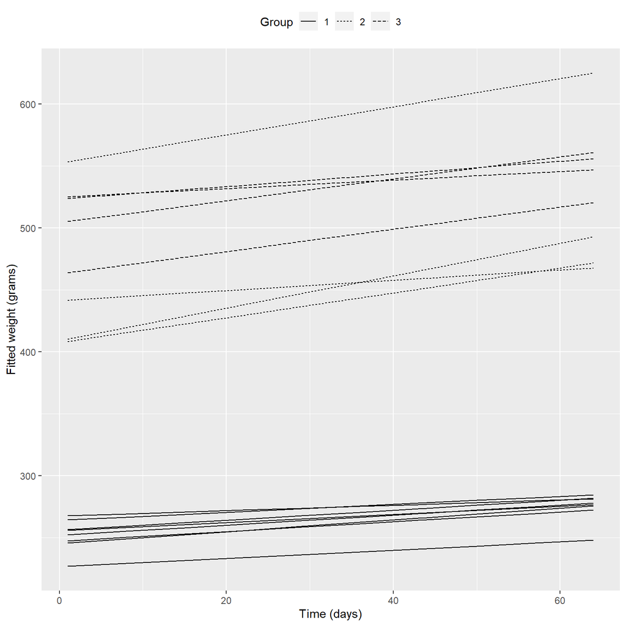

```r
# Create a vector of the fitted values
Fitted <- fitted(RATS_ref2)

# Create a new column fitted to RATSL
RATSL <- RATSL %>% mutate(Fitted = Fitted)

# draw the plot of RATSL with the Fitted values of weight
ggplot(RATSL, aes(x = Time, y = Fitted, group = ID)) +
  geom_line(aes(linetype = Group)) +
  scale_x_continuous(name = "Time (days)", breaks = seq(0, 60, 20)) +
  scale_y_continuous(name = "Fitted weight (grams)") +
  theme(legend.position = "top")
```

(more chapters to be added similarly as we proceed with the course!)